# SMART_analyses_manuscript

20 April 2023

This R code includes the analyses and figures of the SMART manuscript. It includes analyses of Nora Liebers, Peter-Martin Bruch, Junyan Lu, Miguel Hernandez and Tobias Terzer.

# 1 1 Setup

```r
library(knitr)
options(digits=3, width=80)
opts_chunk$set(echo=TRUE,tidy=FALSE,include=TRUE)
```

## 1.1 1.1 Loading libraries

```r
library(ggpmisc)
suppressMessages(library(RColorBrewer))
suppressMessages(library(ggrepel))
suppressMessages(library(gghighlight))
suppressMessages(library(ggbeeswarm))
suppressMessages(library(cowplot))
suppressMessages(library(gridExtra))
suppressMessages(library(drc))
suppressMessages(library(tidyverse))
detach("package:dplyr")
suppressMessages(library(dplyr))
library("survminer")
library("survival")
library("maxstat")
library("forestmodel")
library("forestplot")
library("patchwork")
library("table1")
library("glmnet")
library("corrplot")
library("writexl")

#maintain function of specific R packages
rename <- dplyr::rename
count  <- dplyr::count
filter <- dplyr::filter
```

## 1.2 1.2 Define figure themes

```r
fontsize=18
fontsize_small=10
starsize <- 5
statsize <- 5


theme_figures<- theme_classic()+
  theme(plot.title=element_text(size=fontsize+4, hjust = 0.5, face="bold"),
        text=element_text(size=fontsize),
        axis.text.y =element_text(size=fontsize),
        axis.text.x =element_text(size=fontsize),
        axis.title.y =element_text(size=fontsize+2),
        axis.title.x =element_text(size=fontsize+2),
        axis.line = element_line(size=0.6),
        axis.ticks = element_line(size=1.5),
        legend.text = element_text(size=fontsize),
        legend.title = element_text(size=fontsize+2))
theme_figures_wo_legend<- theme_classic()+
  theme(plot.title=element_text(size=fontsize+4, hjust = 0.5, face="bold"),
        text=element_text(size=fontsize),
        axis.text.y =element_text(size=fontsize),
        axis.text.x =element_text(size=fontsize),
        axis.title.y =element_text(size=fontsize+2),
        axis.title.x =element_text(size=fontsize+2),
        axis.line = element_line(size=0.6),
        axis.ticks = element_line(size=1.5),
        legend.position = "none")

theme_figures_x_angle_45<-theme_classic()+
  theme(plot.title=element_text(size=fontsize+4, hjust = 0.5, face="bold"),
        text=element_text(size=fontsize),
        axis.text.y =element_text(size=fontsize),
         axis.text.x =element_text(size=fontsize, angle=45, vjust=1, hjust=1),
        axis.title.y =element_text(size=fontsize+2),
        axis.title.x =element_text(size=fontsize+2),
        axis.line = element_line(size=0.6),
        axis.ticks = element_line(size=1.5),
        legend.text = element_text(size=fontsize),
        legend.title = element_text(size=fontsize+2))

theme_figures_x_angle_45_wo_legend<-theme_classic()+
  theme(plot.title=element_text(size=fontsize+4, hjust = 0.5, face="bold"),
        text=element_text(size=fontsize),
        axis.text.y =element_text(size=fontsize),
        axis.text.x =element_text(size=fontsize, angle=45, vjust=1, hjust=1),
        axis.title.y =element_text(size=fontsize+2),
        axis.title.x =element_text(size=fontsize+2),
        axis.line = element_line(size=0.6),
        axis.ticks = element_line(size=1.5),
        legend.position = "none")

 theme_figures_x_angle<-theme_classic()+
  theme(plot.title=element_text(size=fontsize+4, hjust = 0.5, face="bold"),
        text=element_text(size=fontsize),
        axis.text.y =element_text(size=fontsize),
         axis.text.x =element_text(size=fontsize, angle=90, vjust=0.5, hjust=1),
        axis.title.y =element_text(size=fontsize+2),
        axis.title.x =element_text(size=fontsize+2),
        axis.line = element_line(size=0.6),
        axis.ticks = element_line(size=1.5),
        legend.text = element_text(size=fontsize),
        legend.title = element_text(size=fontsize+2))

theme_figures_x_angle_wo_legend<-theme_classic()+
  theme(plot.title=element_text(size=fontsize+4, hjust = 0.5, face="bold"),
        text=element_text(size=fontsize),
        axis.text.y =element_text(size=fontsize),
         axis.text.x =element_text(size=fontsize, angle=90, vjust=0.5, hjust=1),
        axis.title.y =element_text(size=fontsize+2),
        axis.title.x =element_text(size=fontsize+2),
        axis.line = element_line(size=0.6),
        axis.ticks = element_line(size=1.5),
        legend.position = "none")

# used colors in combination with alpha=0.85
## primary colors
red1<-"orangered3"
gray1<-"slategray4"
blue1<-"deepskyblue4"

## secondary colors
red2<-"orangered4"
blue2<-"deepskyblue3"
```

## 1.3 1.3 Define functions

### 1.3.1 1.3.1 Functions for Table 1

```r
my.render.cont <- function(x) {
    with(stats.apply.rounding(stats.default(x), digits=3), c("",
        "Median [Min, Max]"=sprintf("%s [%s,  %s]", MEDIAN, MIN, MAX)))
}

my.render.cont_IQR <- function(x) {
    with(stats.apply.rounding(stats.default(x), digits=3), c("",
        "Median [Min, Max]"=sprintf("%s [%s,  %s]", MEDIAN, IQR)))
}

my.render.cat <- function(x) {
    c("", sapply(stats.default(x), function(y) with(
      y,sprintf("%d (%0.0f %%)", FREQ, PCT))))
}
```

### 1.3.2 1.3.2 Functions for Analyses

```r
#standard or Welch's two-sample t-test
t_test <- function(yourTab, var_eq=T){
  pVal <- t.test(metric ~ response, yourTab, var.equal = var_eq)$p.value
}

m_reg <- function(yourTab){
  #pvalue from the response comparison after accounting for tumor infiltration
  return( summary( lm(AUC ~ response + t_infiltration, data = yourTab) )$coefficients[2,4] )
}


###Dose-response curves
fit_log_curve <- function(df, drugname){
  #Fits a 5-parameter logistic model for each in-vivo response and returns:
  # 1) coefficients (b,c,d,e,f) for each model.
  # 2) r^2 between predicted and real values for each model.
  # 3) a df with 1k predicted viability values
  #    for each in-vivo response. This can then be used for building a smooth dose-response curve.

  fun1 <- function(df, drugname){
    # Fit individual curves (5 parameter logistic worked best)
    # parameters and meanings
    # b, c, d, e, f
    # slope, lower, upper, ED50, asymmetry
    mR <- drm(normVal ~ concentration, data = df[df$response == "R",], fct = LL2.5(),
                type = "continuous", upperl = c(NA, 1, NA, 1, NA), lowerl = c(NA, 0, NA, 0, NA))
    mPD <- drm(normVal ~ concentration, data = df[df$response == "PD",], fct = LL2.5(),
                 type = "continuous", upperl = c(NA, 1, NA, 1, NA), lowerl = c(NA, 0, NA, 0, NA))
    #get param coefficients
    coefR <- mR$coef
    coefPD <- mPD$coef
    #evaluate fit
    r2_mR <- round( cor(predict(mR),df[df$response == "R",]$normVal, use = "pairwise.complete.obs")^2, 2)
    r2_mPD <- round( cor(predict(mPD),df[df$response == "PD",]$normVal, use = "pairwise.complete.obs")^2, 2)
    #predict 1k concentrations to smoothen curves in line plot (dose-response curve)
    df_conc <- data.frame(concentration = seq(min(df$concentration), max(df$concentration), length.out=1000))
    predi_R <- predict(mR, newdata = df_conc )
    predi_PD <- predict(mPD, newdata = df_conc )

    return( list( coefR,
                  coefPD,
                  r2_mR,
                  r2_mPD,
                  tibble(name = rep(drugname, 2000),
                         response = c(rep("R", 1000), rep("PD", 1000)) ,
                         concentration = c( seq(min(df$concentration), max(df$concentration), length.out=1000),
                                            seq(min(df$concentration), max(df$concentration), length.out=1000) ) ,
                         viab_pred = c(predi_R,predi_PD)) ) )
  }
  #function if error
  errorfun <- function(){
      #if fitting error, return a df with NAs
      return( list( c(NA,NA,NA,NA,NA),
                    c(NA,NA,NA,NA,NA),
                    NA,
                    NA,
                    tibble(name = drugname, response = NA, concentration = NA, viab_pred = NA) ) )}

  #call functions
  out_lst <- tryCatch( fun1(df, drugname),
                       error = function(e){T} )
  #handle error and return
  if ( typeof(out_lst) == typeof(T) ){return( errorfun() )} else{return( out_lst )}
}

#Junyan's
#To calculate the area under the curve based on the trapezoidal rule
calcAUC <- function(value, conc) {
    #value is a vector of normalized viability values
    #conc is a vector of concentrations.

    valueConc <- data.frame(viab=value, conc=conc)
    valueConc <- valueConc[order(valueConc$conc),]
    areaTotal <- 0
    for (i in seq(length(value)-1)) {
        areaEach <- (valueConc$viab[i] + valueConc$viab[i+1])*log(valueConc$conc[i+1]/valueConc$conc[i])*0.5
        areaTotal <- areaTotal + areaEach
    }
    areaTotal/log(valueConc[nrow(valueConc),]$conc/valueConc[1,]$conc)
}

#Junyan's miscelaneous custom functions: library(jyluMisc)
#it creates a pdf doc where it arranges the plots contained in a plotList on a grid
makepdf <- function(x, name, ncol = 3, nrow = 2, figNum =NULL, width =20, height = 12) {
  require(gridExtra)
  #figs per page
  if (is.null(figNum)) figNum = ncol*nrow
  if (length(x) == 0) return(NULL)
  #create empty pdf doc with dims
  pdf(name, width = width, height = height)
  #iterate over len of plots in plotList by figNum (e.g., 8 by 8 = 1, 9, 17...)
  for (i in seq(1, length(x), by = figNum)) {
    #print(names(x)[i])
    j  <- min(i + figNum - 1, length(x))
    #arrange plots in grid
    do.call(grid.arrange, c(x[i:j], ncol = ncol, nrow = nrow))
  }
  dev.off() %>% invisible #close pdf
}


# Functions for elastic net regression #
repeated_glmnet <- function(X, Y, alpha = alpha, type.measure = "auc", nlambda, nfolds, ncv = 1000, family = "binomial"){
  folds.list <- lapply(1:ncv, function(x){return(balanced_folds(Y, nfolds))})
  lasso.models <- lapply(X = folds.list, FUN = function(folds){
    return(cv.glmnet(X, Y, alpha = alpha, type.measure = type.measure, intercept = TRUE, standardize = FALSE, nlambda = nlambda, foldid = folds, family = family))
  })

  tmp <- lapply(lasso.models, FUN = function(x){
    lambda.min <- x$lambda.min
    index.min <- x$lambda == lambda.min
    cvm <- x$cvm[index.min]
    coef <- x$glmnet.fit$beta[,index.min]
    names(coef) <- rownames(x$glmnet.fit$beta)
    return(list(lambda = lambda.min, cvm = cvm, coef = coef))
  })

  coefficients <- matrix(unlist(lapply(tmp, FUN = function(x){
    return(x$coef)})), ncol = length(tmp), byrow = FALSE)
  rownames(coefficients) <- names(tmp[[1]]$coef)

  cvm <- sapply(tmp, FUN = function(x){
    return(x$cvm)
  })

  lambda <- sapply(tmp, FUN = function(x){
    return(x$lambda)
  })
  return(list(coef = coefficients, cvm = cvm, lambda = lambda))
}

give_repeated_lasso_results <- function(lasso.models, type.measure = "auc"){
  coef_mat <-lasso.models$coef
  median_coef <- apply(coef_mat, MARGIN = 1, FUN = function(x){
    return(ifelse(any(x != 0), median(x[x != 0]), 0))})

  proportion_selected <- apply(coef_mat, MARGIN = 1, FUN = function(x){
    return(sum(x != 0)/length(x))})
  cvms <- lasso.models$cvm

  median_auc <- sapply(1:nrow(coef_mat), FUN = function(cur_index){
    relevant_cols <- which(coef_mat[cur_index,] != 0)
    return(ifelse(length(relevant_cols) > 0, median(cvms[relevant_cols]), 0.5))})

  tmp.frame <- data.frame(Covariate_label = rownames(coef_mat), medianOR = median_coef, Proportion_selected = proportion_selected, median_AUROC  = median_auc)
  rownames(tmp.frame) <- tmp.frame$Covariate_label
  tmp.frame$medianOR <- case_when(tmp.frame$Covariate_label %in% c("Vidaza", "Azaguanin", chemotherapies) ~ exp(tmp.frame$medianOR/10), TRUE ~ exp(tmp.frame$medianOR))
  tmp.frame <- tmp.frame[order(tmp.frame$Proportion_selected, decreasing = TRUE),]
  rownames(tmp.frame)

  #Compute proportions matrix
  coef_mat <- coef_mat[rownames(tmp.frame),]
  mat.tmp <-matrix(0, nrow = nrow(coef_mat), ncol = nrow(coef_mat))
  for(i in 1:nrow(mat.tmp))
  {
    relevant_cols <- which(coef_mat[i,] != 0)
    for(j in 1:nrow(mat.tmp))
    {
      if(length(relevant_cols) != 0){
        mat.tmp[i,j] <- sum(coef_mat[j, relevant_cols] != 0) /length(relevant_cols)
      }
      else
      {
        mat.tmp[i,j] <- 0
      }
    }
  }
  rownames(mat.tmp) <- colnames(mat.tmp) <- rownames(coef_mat)
  diag(mat.tmp) <- proportion_selected[rownames(mat.tmp)]
  return(list(overview_frame = tmp.frame, proportions.mat = mat.tmp))
}

# function to select folds in cv in a balanced fashion
balanced.folds.new <- function (y, nfolds = min(min(table(y)), 10))
{
  totals <- table(y)
  fmax <- max(totals)
  nfolds <- min(nfolds, fmax)
  nfolds = max(nfolds, 2)
  folds <- as.list(seq(nfolds))
  yids <- split(seq(y), y)
  bigmat <- matrix(NA, ceiling(fmax/nfolds) * nfolds, length(totals))
  for (i in seq(totals)) {
    # cat(i)
    if (length(yids[[i]]) > 1) {
      bigmat[seq(totals[i]), i] <- sample(yids[[i]])
    }
    if (length(yids[[i]]) == 1) {
      bigmat[seq(totals[i]), i] <- yids[[i]]
    }
  }
  smallmat <- matrix(bigmat, nrow = nfolds)
  smallmat <- pamr:::permute.rows(t(smallmat))
  res <- vector("list", nfolds)
  for (j in 1:nfolds) {
    jj <- !is.na(smallmat[, j])
    res[[j]] <- smallmat[jj, j]
  }
  return(res)
}

balanced_folds <- function (class.column.factor, cross.outer){
  sampleOfFolds <- get("balanced.folds.new")(class.column.factor, nfolds = cross.outer)
  permutated.cut <- rep(0, length(class.column.factor))
  for (sample in 1:cross.outer){
    # cat(sample, "\n")
    permutated.cut[sampleOfFolds[[sample]]] <- sample
  }
  return(permutated.cut)
}

#Function to format floats
formatNum <- function(i, limit = 0.01, digits =1, format="e") {
  r <- sapply(i, function(n) {
    if (n < limit) {
      formatC(n, digits = digits, format = format)
    } else {
      format(n, digits = digits)
    }
  })
  return(r)
}

# scale matrics
mscale <- function(x, center = TRUE, scale = TRUE, censor = NULL, useMad = FALSE){
    if (scale & center) {
        if (useMad) {
            x.scaled <- apply(x, 1, function(y) (y-median(y,na.rm = T))/meanAD(y))
        } else {
            x.scaled <- apply(x, 1, function(y) (y-mean(y,na.rm=T))/sd(y,na.rm = T))
        }
    } else if (center & !scale) {
        if (useMad) {
            x.scaled <- apply(x, 1, function(y) (y-median(y,na.rm=T)))
        } else {
            x.scaled <- apply(x, 1, function(y) (y-mean(y,na.rm=T)))
        }
    } else if (!center & scale) {
        if (useMad) {
            x.scaled <- apply(x, 1, function(y) y/meanAD(y))
        } else {
            x.scaled <- apply(x, 1, function(y) y/sd(y,na.rm = T))
        }
    } else {
        x.scaled <- t(x)
    }

    if (!is.null(censor)) {
        if (length(censor) == 1) {
            x.scaled[x.scaled > censor] <- censor
            x.scaled[x.scaled < -censor] <- -censor
        } else {
            x.scaled[x.scaled > censor[2]] <- censor[2] #higher limit
            x.scaled[x.scaled < censor[1]] <- censor[1] #lower limit
        }
    }
    return(t(as.matrix(x.scaled)))
}
```

# 2 2 Data read in and preprocessing

## 2.1 2.1 File path

```r
# Modify if necessary

filepath <-"../../"
```

## 2.2 2.2 Load processed data

```r
load(paste0(filepath,"data/SMARTrial_data.RData"))

screenData<-left_join(screenData, df_drugs, by="Drug")
data_all<-left_join(data_all, df_drugs, by="Drug")
```

Explanation of all datasets:  
- screenData: processed ex-vivo raw data  
- data_all: includes in-vivo and ex-vivo data of all 80 patients after data quality control  
- df_chemo: includes only patients with chemotherapy and evaluable response (n=46) after data quality control, includes AUC and normalized viability per concentration and drug  
- df_drugs: list and metadata of drugs used ex-vivo

# 3 3 Overview drugs

## 3.1 3.1 Figure: overview drugs

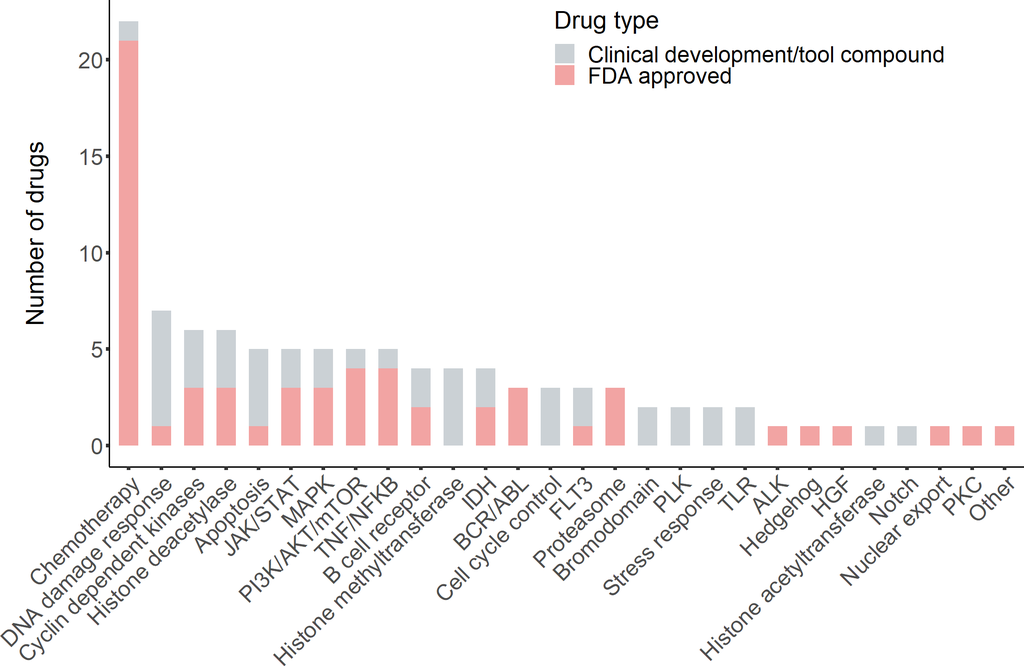

```r
# prepare data
drugs_overview <-df_drugs %>% dplyr::count(pathway, FDA_approved) %>%
         left_join(., dplyr::count(df_drugs, pathway), by="pathway")

drugs_overview$pathway <-factor(drugs_overview$pathway, levels=c("ABL (BCR)", "ALK", "Apoptosis", "BCR", "Bromodomain", "CDK", "Cell cycle" , "Chemotherapy", "DDR", "FLT3", "Hedgehog", "HGF", "Histone acetyltransferase", "Histone deacetylase", "Histone methyltransferase", "IDH", "JAK/STAT", "MAPK", "Notch", "Nuclear export", "PI3K/AKT/mTOR", "PKC", "PLK", "Promiscuous" , "Proteasome"    , "Stress response", "TLR", "TNF/NFKB" ),
labels=c("BCR/ABL", "ALK", "Apoptosis", "B cell receptor", "Bromodomain", "Cyclin dependent kinases", "Cell cycle control" , "Chemotherapy", "DNA damage response", "FLT3", "Hedgehog", "HGF", "Histone acetyltransferase", "Histone deacetylase", "Histone methyltransferase", "IDH", "JAK/STAT", "MAPK", "Notch", "Nuclear export", "PI3K/AKT/mTOR", "PKC", "PLK", "Other" , "Proteasome", "Stress response", "TLR", "TNF/NFKB" ))

# define figure theme
theme_tmp<-theme_classic()+
  theme(plot.title=element_text(size=fontsize+4, hjust = 0.5, face="bold"),
        text=element_text(size=fontsize),
        axis.text.y =element_text(size=fontsize),
         axis.text.x =element_text(size=fontsize, angle=45, vjust=1, hjust=1),
        axis.title.y =element_text(size=fontsize+2),
        axis.title.x =element_text(size=fontsize+2),
        axis.line = element_line(size=0.6),
        axis.ticks = element_line(size=1.5),
        legend.text = element_text(size=fontsize),
        legend.title = element_text(size=fontsize+2),
        legend.position = c(0.7, 0.9))

# plot
ggplot(data=drugs_overview, aes(x=reorder(pathway, -n.y), y=n.x, fill=as.character(FDA_approved)))+
         geom_bar(stat = "identity", width=0.6)+
         scale_fill_manual(values=c("#cbd1d5", "#f2a4a3"), name="Drug type", label=c("Clinical development/tool compound", "FDA approved"))+
         ylab("\n\nNumber of drugs\n")+
         xlab("")+
         theme_tmp
```

```r
ggsave(width = 12, height =8, path=(paste0(filepath,"docs")), filename = "Figure_1B_Compound_library.svg")

remove(drugs_overview, theme_tmp)
```

## 3.2 3.2 Supplementary table: Drug list

For appendix: includes the pathway, target, Supplier of each drug

```r
'df_drugs_supp<-df_drugs%>%select(Drug, pathway, target, Supplier)%>%filter(Drug!="Bortezomib + Cytarabine(800nM)")%>%rename(Compound="Drug")%>%rename(Main.targets_mode.of.action="target")%>%rename(Simplified.drug.class="pathway")

write_xlsx(df_drugs_supp,"docs/table_S1_drugs.xlsx")
remove(df_drugs_supp)'
```

```
## [1] "df_drugs_supp<-df_drugs%>%select(Drug, pathway, target, Supplier)%>%filter(Drug!=\"Bortezomib + Cytarabine(800nM)\")%>%rename(Compound=\"Drug\")%>%rename(Main.targets_mode.of.action=\"target\")%>%rename(Simplified.drug.class=\"pathway\")\n\nwrite_xlsx(df_drugs_supp,\"docs/table_S1_drugs.xlsx…
```

# 4 4 Patient characteristics

## 4.1 4.1 Table 1

```r
# preparation
df_invivo$diagnosis_summarized <-factor(df_invivo$diagnosis, levels=c("AML", "ALL","DLBCL", "BL", "FL", "MCL", "CLL", "B-PLL", "T-PLL", "T-NHL" ),
                       labels=c("AML", "ALL", "DLBCL", "Burkitt lymphoma", "Follicular lymphoma", "Mantle cell lymphoma", "CLL", "B-PLL", "T-PLL", "T-cell lymphoma, NOS" ))

label(df_invivo$age) <-"Age (years)"
label(df_invivo$diagnosis_summarized) <-"Diagnosis"
label(df_invivo$time_from_ED_dich) <-"Time from initial diagnosis (months)"
label(df_invivo$lines_pretreatment_cat) <-"Prior lines of treatment"
label(df_invivo$tumor_infiltration) <-"Tumor infiltration of sample"
label(df_invivo$Treatment_type) <-"Prescribed treatment at study entry"

df_invivo$material <-factor(df_invivo$material, levels=c("PB", "BM", "LN"),
                                       labels=c("Periphal blood", "Bone marrow", "Lymph node"))
label(df_invivo$material) <-"Tumor sample origin"

df_invivo<-df_invivo %>%
  mutate(Treatment_type=gsub("mall molecules","mall molecule inhibitors",Treatment_type))

# table 1 printing
table1(~ Sex + age + diagnosis_summarized + time_from_ED_dich + lines_pretreatment_cat+ material +tumor_infiltration +Treatment_type,  data=df_invivo, overall="Total",  render.continuous=my.render.cont, render.categorical=my.render.cat)
```

|  | Total (N=80) |
| --- | --- |
| Sex |  |
| Male | 48 (60 %) |
| Female | 32 (40 %) |
| Age (years) |  |
| Median [Min, Max] | 68.5 [20.0, 91.0] |
| Diagnosis |  |
| AML | 34 (42 %) |
| ALL | 2 (2 %) |
| DLBCL | 4 (5 %) |
| Burkitt lymphoma | 1 (1 %) |
| Follicular lymphoma | 3 (4 %) |
| Mantle cell lymphoma | 5 (6 %) |
| CLL | 25 (31 %) |
| B-PLL | 1 (1 %) |
| T-PLL | 4 (5 %) |
| T-cell lymphoma, NOS | 1 (1 %) |
| Time from initial diagnosis (months) |  |
| >12 | 31 (39 %) |
| ≤12 | 49 (61 %) |
| Prior lines of treatment |  |
| ≥3 | 6 (8 %) |
| 0 | 54 (68 %) |
| 1 | 11 (14 %) |
| 2 | 9 (11 %) |
| Tumor sample origin |  |
| Periphal blood | 59 (74 %) |
| Bone marrow | 12 (15 %) |
| Lymph node | 9 (11 %) |
| Tumor infiltration of sample |  |
| Median [Min, Max] | 84.5 [52.0, 99.0] |
| Prescribed treatment at study entry |  |
| Chemotherapy | 28 (35 %) |
| Chemotherapy + small molecule inhibitors | 7 (9 %) |
| Immuno-Chemotherapy | 16 (20 %) |
| Immunotherapy | 2 (2 %) |
| Small molecule inhibitors | 27 (34 %) |

## 4.2 4.1.1 Plot of diagnosis

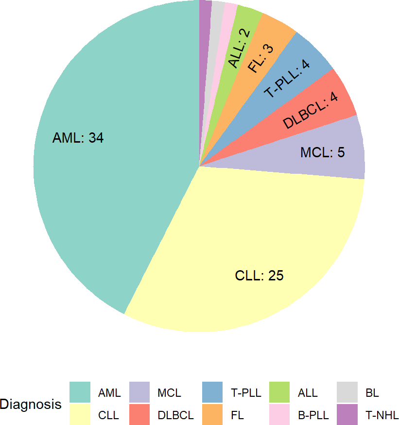

```r
df_invivo %>%
  dplyr::count(diagnosis) %>%
  mutate(diagnosis=factor(diagnosis, levels= arrange(dplyr::count(df_invivo, diagnosis),desc(n))$diagnosis )) %>%

  ggplot(aes(x="", y=n, fill=diagnosis))+
  geom_bar(stat="identity", width=1) +
  coord_polar("y", start=0)+
  geom_text(aes(x=1.25, angle=c(70,0,0,0,0,30,55,0,0,40),  label = ifelse(n>1,paste0(diagnosis, ": ", n),"")), position = position_stack(vjust=0.5)) +
  theme_void()+
  theme(legend.position = "bottom")+
  scale_fill_brewer(palette="Set3")+
  labs(fill="Diagnosis")
```

```r
ggsave(width = 6, height = 4, path=(paste0(filepath,"docs")), filename = "Figure_2_Diagnosis_Piechart.svg")
```

## 4.3 4.1.1 Plot of SMARTrial subcohorts

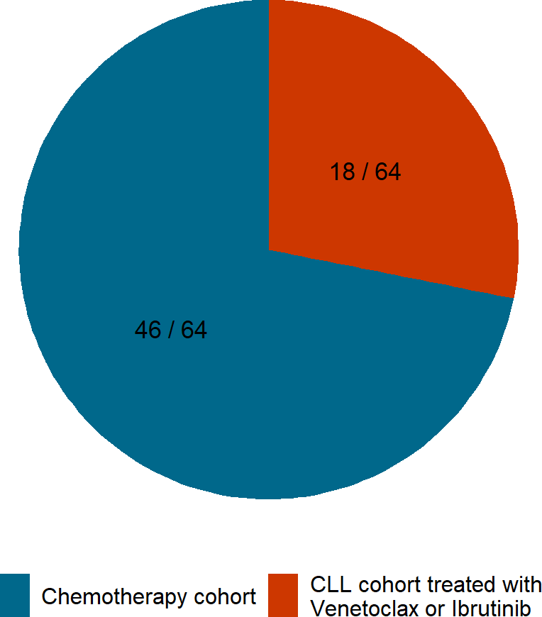

```r
tibble("Subcohort"=c("Chemotherapy cohort", "CLL cohort treated with \nVenetoclax or Ibrutinib"), "n"=c(46,18)) %>%


  ggplot(aes(x="", y=n, fill=Subcohort))+
  geom_bar(stat="identity", width=1) +
  coord_polar("y", start=0)+
  geom_text(aes(x=1, size=5, label = ifelse(n>1,paste0( n, " / 64"),"")), position = position_stack(vjust=0.5)) +
  theme_void()+
  theme(legend.position = "bottom", legend.text = element_text(size=12))+
  scale_fill_manual(values=c(blue1, red1))+
  guides(size="none", x="none")+
  labs(fill="")
```

```r
ggsave(width = 6, height = 4, path=(paste0(filepath,"docs")), filename = "Figure_2_Subcohort_Piechart.svg")
```

## 4.4 4.2 Patient list

For appendix: includes clinical data for each patient

```r
df_patients_supp<-df_invivo%>%select(patientID, diagnosis, age, Sex, material, tumor_infiltration, lines_pretreatment, treatment_spec, Response_def_parameter_final,  Resp_protocol, Death, time_EFS)
df_patients_supp<-df_patients_supp%>%mutate(time_EFS=ifelse(Resp_protocol=="na", "na", time_EFS))

write_xlsx(df_patients_supp,path=paste0(filepath,"docs/table_S1_SMARTrial_patients.xlsx"))

remove(df_patients_supp)
```

## 4.5 4.3 Median Follow-up

Calculated according to the reverse Kaplan-Meier method

```r
fit_FU <- survfit(Surv(time_OS/365, Death_r) ~ 1, data=df_invivo)
surv_median(fit_FU)
```

```
##   strata median lower upper
## 1    All   2.11  1.95  2.62
```

```r
remove(fit_FU)
```

## 4.6 4.4 Time from Diagnosis to Treatment initiation

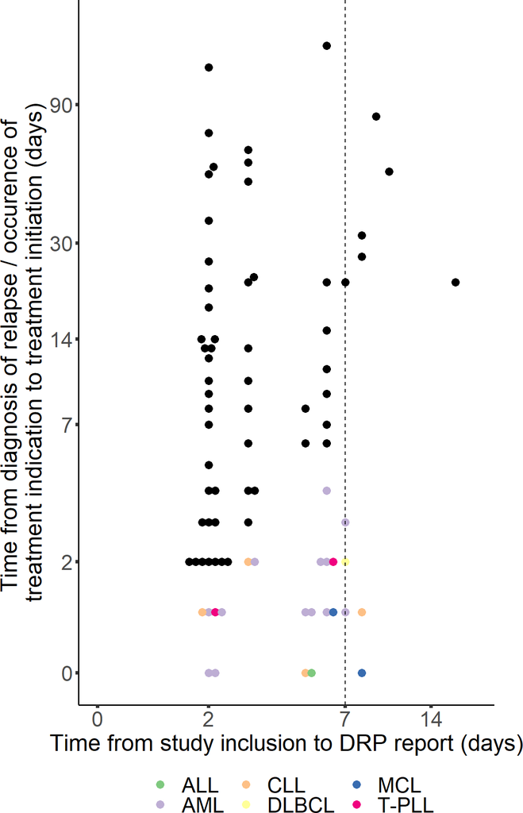

```r
my_colors <- c("#7fc97f","#beaed4", "#fdc086", "#ffff99", "#386cb0" , "#f0027f")
# add names so bar for 'c' gets fill, too
names(my_colors) <- c("ALL","AML", "CLL","DLBCL", "MCL", "T-PLL")

df_invivo %>%
  mutate(time_report=as.numeric(time_report), time_diarel_treatment=as.numeric(time_diarel_treatment)) %>%
  mutate(colorscale=ifelse(time_report>time_diarel_treatment, diagnosis, "Report in time for treatment")) %>%

  ggplot(aes(x=time_report, y=time_diarel_treatment))+
  geom_beeswarm(aes(color=colorscale), cex=1.7, size=3)+
  # scale_color_brewer(palette = "Paired")+
  # scale_color_manual(values=c("#7fc97f","#beaed4", "#fdc086", "#ffff99", "#386cb0" ,"#f0027f", "red"), limits=c("ALL","AML", "CLL","DLBCL", "MCL", "T-PLL"))+
  scale_color_manual(values = my_colors,limits = c("ALL","AML", "CLL","DLBCL", "MCL", "T-PLL"), na.value = "black")+
  theme_figures+
  scale_y_continuous(trans=scales::pseudo_log_trans(base = 10), limits = c(0,160), breaks = c(0,2,7,14,30,90))+
  scale_x_continuous(trans=scales::pseudo_log_trans(base = 10), limits = c(0,20), breaks = c(0,2,7,14))+
  theme(legend.position = "bottom")+
  coord_fixed()+
  geom_vline(xintercept = 7, linetype=2)+
  labs(color="", x="Time from study inclusion to DRP report (days)", y="Time from diagnosis of relapse / occurence of \ntreatment indication to treatment initiation (days)" )
```

```r
df_invivo %>%
  filter(time_report>time_diarel_treatment) %>%
  group_by(diagnosis) %>%
  count()
```

```
## # A tibble: 6 × 2
## # Groups:   diagnosis [6]
##   diagnosis     n
##   <chr>     <int>
## 1 ALL           1
## 2 AML          13
## 3 CLL           4
## 4 DLBCL         1
## 5 MCL           2
## 6 T-PLL         2
```

```r
df_invivo %>%
  mutate(time_report=as.numeric(time_report), time_diarel_treatment=as.numeric(time_diarel_treatment),
         delaybyDRP=time_report-time_diarel_treatment) %>%
  filter(delaybyDRP>0) %>%
  group_by(delaybyDRP) %>%
  count()
```

```
## # A tibble: 7 × 2
## # Groups:   delaybyDRP [7]
##   delaybyDRP     n
##        <dbl> <int>
## 1          1     6
## 2          2     3
## 3          4     6
## 4          5     5
## 5          6     1
## 6          7     1
## 7          8     1
```

```r
df_invivo %>%
  group_by(diagnosis) %>%
  summarise(median.time.to.treatment=median(time_diarel_treatment), range=paste0(min(time_diarel_treatment), " - ", max(time_diarel_treatment)), count = n()) %>%
  arrange(desc(count))
```

```
## # A tibble: 10 × 4
##    diagnosis median.time.to.treatment range   count
##    <chr>                        <dbl> <chr>   <int>
##  1 AML                            2.5 0 - 15     34
##  2 CLL                           21   0 - 144    25
##  3 MCL                            8   0 - 49      5
##  4 DLBCL                         14.5 2 - 27      4
##  5 T-PLL                          2   1 - 6       4
##  6 FL                            32   22 - 82     3
##  7 ALL                            5   0 - 10      2
##  8 B-PLL                          6   6 - 6       1
##  9 BL                             8   8 - 8       1
## 10 T-NHL                         22   22 - 22     1
```

## 4.7 4.5 Overview of the drug respone pattern

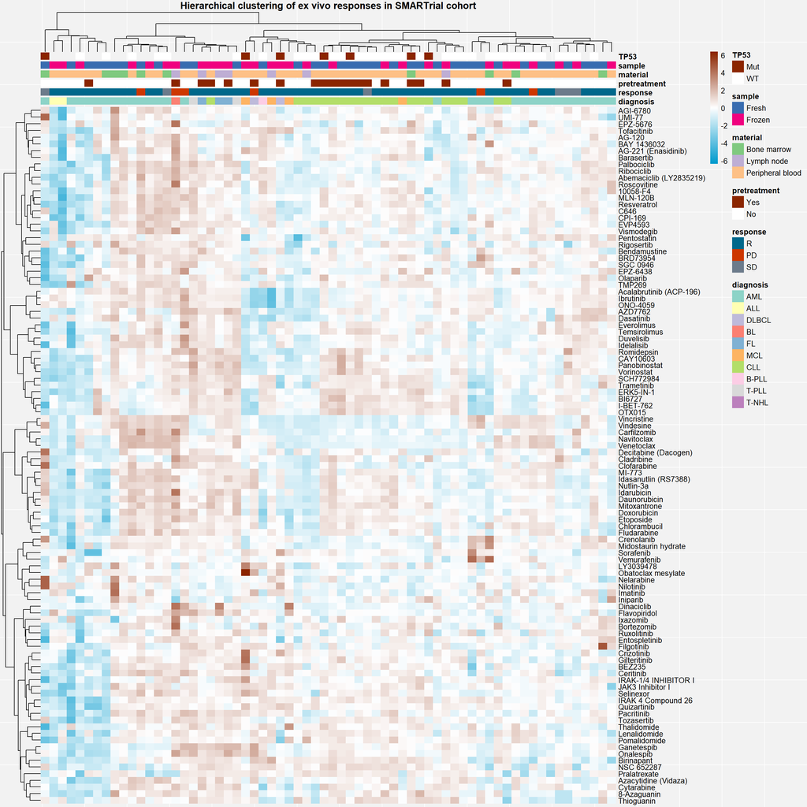

```r
df_forClustering <- data_all %>% filter(!Resp_protocol %in% c("",NA,"na")) %>%
    dplyr::rename(response = Resp_protocol, pretreatment = Pretreatment) %>%
    mutate(frozen = screenData[match(patientID, screenData$patientID),]$frozen) %>%
    mutate(material = ifelse(material == "BM","Bone marrow",
                           ifelse(material == "LN","Lymph node", "Peripheral blood")),
         sample = ifelse(frozen == TRUE,"Frozen","Fresh"),
         TP53 = ifelse(TP53 %in% "1","Mut", ifelse(TP53 %in% "0", "WT", NA)))

viabMat <- df_forClustering %>% distinct(patientID, Drug, AUC) %>%
    pivot_wider(names_from = patientID, values_from = AUC) %>%
    column_to_rownames("Drug") %>% as.matrix()
viabMat <- viabMat[,complete.cases(t(viabMat))]

viabMat.scaled <-  mscale(viabMat, censor =4)

annoCol <- distinct(df_forClustering, patientID, diagnosis, response, pretreatment, material, sample, TP53) %>%
    data.frame() %>% column_to_rownames("patientID")

#define annotaiton colors
colorAnno <- list(diagnosis = structure(RColorBrewer::brewer.pal(10,"Set3"),
                                        names = c("AML", "ALL","DLBCL", "BL", "FL", "MCL", "CLL", "B-PLL", "T-PLL", "T-NHL" )),
                  TP53 = c(Mut = red2, WT = "white"),
                  pretreatment = c(Yes = red2, No = "white"),
                  sample = c(Fresh = "#386cb0", Frozen = "#f0027f"),
                  response = c(R = blue1, PD = red1, SD = gray1),
                  material = c(`Bone marrow` = "#7fc97f", `Lymph node` = "#beaed4", `Peripheral blood` = "#fdc086")
                  )

p<-pheatmap::pheatmap(viabMat.scaled, annotation_col = annoCol, scale = "row", clustering_method = "ward.D2",
                   color=colorRampPalette(c(blue2, "white", red2))(100),
                   show_colnames = FALSE, annotation_colors = colorAnno,
                   main = "Hierarchical clustering of ex vivo responses in SMARTrial cohort", silent = TRUE)
plot(p$gtable)
```

```r
ggsave("../../docs/Figure_S4.png", plot = p$gtable, height = 15, width =15)
ggsave("../../docs/Figure_S4.pdf", plot = p$gtable, height = 15, width =15)
```

# 5 5 Primary endpoint

## 5.1 5.1 Calculation of primary endpoint

```r
df_invivo%>%summarize(
         mean.timelabreport=mean(time_report),
         median.timelabreport=median(time_report),
         min.timelabreport=min(time_report),
         max.timelabreport=max(time_report))
```

```
## # A tibble: 1 × 4
##   mean.timelabreport median.timelabreport min.timelabreport max.timelabreport
##   <drtn>             <drtn>               <drtn>            <drtn>
## 1 3.98 days          3 days               2 days            17 days
```

```r
#calculate rate with labreport during 7 days
df_prim_endpoint<-df_invivo%>% select(patientID, time_report) %>% dplyr::mutate(within7d=ifelse(time_report<=7, 1, 0)) %>% dplyr::mutate(time_to_analysis=ifelse(time_report<=7, "within 7 days", "more than 7 days")) %>%
   dplyr::mutate(duration_analysis_cat=case_when(time_report<=3 ~ "within 3 days", (time_report>4 &time_report<=7) ~ "within 4-7 days", (time_report>=8 &time_report<=10) ~ "within 8-10 days", time_report>10 ~ "more than 10 days" ))

bintest <- binom.test(sum(df_prim_endpoint$within7d), nrow(df_prim_endpoint))
bintest
```

```
##
##  Exact binomial test
##
## data:  sum(df_prim_endpoint$within7d) and nrow(df_prim_endpoint)
## number of successes = 73, number of trials = 80, p-value = 6e-15
## alternative hypothesis: true probability of success is not equal to 0.5
## 95 percent confidence interval:
##  0.828 0.964
## sample estimates:
## probability of success
##                  0.912
```

```r
cat("For ", sum(df_prim_endpoint$within7d)," of ", length(df_prim_endpoint$within7d), "patients the primary endpoint was reached. Therefore, for ", (bintest$estimate*100),"% (",round(bintest$conf.int[1],3),",", round(bintest$conf.int[2],3),") of participants ex-vivo drug testing was performed within a week.")
```

```
## For  73  of  80 patients the primary endpoint was reached. Therefore, for  91.2 % ( 0.828 , 0.964 ) of participants ex-vivo drug testing was performed within a week.
```

```r
remove(bintest)

#calculate rate with labreport during 3 days
df_invivo%>% select(patientID,time_report) %>% dplyr::mutate(within3d=ifelse(time_report<4, 1, 0)) %>% dplyr::count(within3d) %>% mutate(percent = n / sum(n)*100)
```

```
## # A tibble: 2 × 3
##   within3d     n percent
##      <dbl> <int>   <dbl>
## 1        0    30    37.5
## 2        1    50    62.5
```

## 5.2 5.2 Visualisation primary endpoint (barplot)

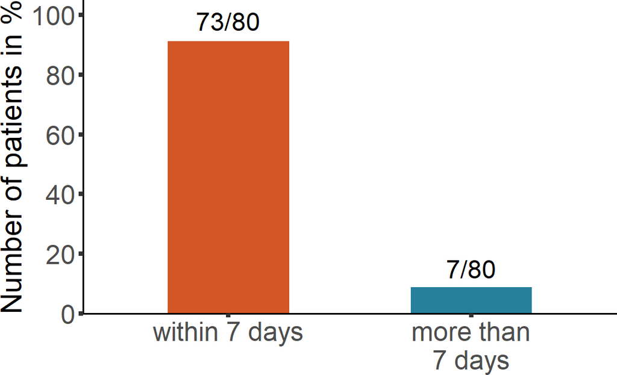

```r
df_prim_endpoint<-df_prim_endpoint%>% dplyr::count(time_to_analysis) %>% mutate(percent = n / sum(n)*100)

df_prim_endpoint$time_to_analysis<-factor(df_prim_endpoint$time_to_analysis, levels=c("within 7 days", "more than 7 days"), labels=c("within 7 days", "more than\n7 days"))

ggplot(data=df_prim_endpoint, aes(x=as.factor(time_to_analysis), y=percent, fill=time_to_analysis))+
  geom_bar(stat="identity", width=0.5, alpha=0.85)+
  xlab("")+
  annotate("text", x=1, y=98, label= "73/80", size=6)+
  annotate("text", x=2, y=15, label= "7/80", size=6)+
  scale_y_continuous("Number of patients in %", limits = c(0, 100), breaks=c(0, 20, 40, 60, 80, 100), expand = expansion(mult = c(0, 0.05)))+
  scale_fill_manual(values=c(red1, blue1), name="Time to report")+
  theme_figures_wo_legend
```

```r
ggsave(width = 6, height = 4, path=(paste0(filepath,"docs")), filename = "Figure_2B_Time_to_report.svg")


# remove(df_prim_endpoint)
```

# 6 6 Pathways and drug difference between in-vivo response groups in chemotherapy patients

## 6.1 6.1 Prepare base data frame

```r
df_chemo$Pathway <-factor(df_chemo$Pathway,
                                levels=c("ABL (BCR)", "ALK", "Apoptosis", "BCR", "Bromodomain", "CDK", "Cell cycle" ,
                                         "Chemotherapy", "DDR", "FLT3", "Hedgehog", "HGF", "Histone acetyltransferase",
                                         "Histone deacetylase", "Histone methyltransferase", "IDH", "JAK/STAT", "MAPK",
                                         "Notch", "Nuclear export", "PI3K/AKT/mTOR", "PKC", "PLK", "Promiscuous" , "Proteasome",
                                         "Stress response", "TLR", "TNF/NFKB" ),
                                labels=c("BCR/ABL", "ALK", "Apoptosis", "B cell receptor", "Bromodomain", "Cyclin dependent kinases",
                                         "Cell cycle control" , "Chemotherapy", "DNA damage response", "FLT3", "Hedgehog", "HGF",
                                         "Histone acetyltransferase", "Histone deacetylase", "Histone methyltransferase", "IDH",
                                         "JAK/STAT", "MAPK", "Notch", "Nuclear export", "PI3K/AKT/mTOR", "PKC", "PLK", "Other" ,
                                         "Proteasome", "Stress response", "TLR", "TNF/NFKB" ))

df_chemo_bckup <- rename(df_chemo, response = resp_protocol)

df_chemo <- filter(df_chemo, resp_protocol != "SD") %>%
  #rename some cols
  rename(response = resp_protocol) %>%
  #AUC per pathway per patient
  group_by(patientID, Pathway) %>% mutate(AUC_pathway_patient = mean(AUC)) %>%
  ungroup()
```

## 6.2 6.2 Perform statistical tests and figures

### 6.2.1 6.2.1 t-tests by drug, R vs PD

```r
  #eliminate conc-specific rows/cols
df_p_drugAUC <- select(df_chemo,
                       -concentration, -concIndex, -normVal, -AUC_pathway_patient) %>% unique() %>%
  #"AUC" to "metric" for functions
  mutate(metric = AUC) %>%
  #perform standard two-sample t-test
  group_by(name) %>% nest() %>%
  mutate(pval = map(data, t_test) ) %>%
  unnest( c(data, pval) ) %>% ungroup() %>%
  #how many drugs per pathway
  group_by(Pathway) %>% mutate( n_drugs_pathway = length(unique(name)) ) %>%
  #How many significant drugs per pathway (raw p 0.05)
  mutate( n_sign_drugs_pathway = length( unique(name[pval < 0.05]) ) ) %>%
  #Prop of significant drugs per pathway
  mutate(prop_sig_pathway = (n_sign_drugs_pathway/n_drugs_pathway)) %>%
  ungroup() %>%
  #arrange by pathway with highest prop and by most significant drugs
  arrange( desc(prop_sig_pathway), Pathway, pval )

df_p_drugAUC %>% select(Pathway, name, prop_sig_pathway, pval) %>% unique() %>%
  mutate_if(is.numeric, formatC, digits=2) %>% DT::datatable(width = 700)
```

|  | Pathway | name | prop_sig_pathway | pval |
| --- | --- | --- | --- | --- |
| 1 | Histone acetyltransferase | C646 | 1 | 0.036 |
| 2 | Other | Resveratrol | 1 | 0.049 |
| 3 | Stress response | Ganetespib | 1 | 0.0059 |
| 4 | Stress response | Onalespib | 1 | 0.016 |
| 5 | Cyclin dependent kinases | Palbociclib | 0.67 | 0.01 |
| 6 | Cyclin dependent kinases | Dinaciclib | 0.67 | 0.012 |
| 7 | Cyclin dependent kinases | Abemaciclib (LY2835219) | 0.67 | 0.013 |
| 8 | Cyclin dependent kinases | Ribociclib | 0.67 | 0.024 |
| 9 | Cyclin dependent kinases | Flavopiridol | 0.67 | 0.06 |
| 10 | Cyclin dependent kinases | Roscovitine | 0.67 | 0.075 |

[output cut: 94 more lines]

## 6.3 6.3 Figure 3A: Association between pathway ex vivo response and in vivo response in patients treated with chemotherapy.

### 6.3.1 6.3.1 Prepare data

```r
#mean per pathway per in-vivo group
plotTab <- group_by(df_p_drugAUC, Pathway, response) %>%
  summarise(AUC_pathway_response = mean(AUC)) %>%
  #difference R vs PD
  group_by(Pathway) %>%
  summarise(diff_RvsPD = AUC_pathway_response[response == "R"] - AUC_pathway_response[response == "PD"],
            direction = ifelse(diff_RvsPD < 0,"decreased","increased")) %>% ungroup() %>%
  #arrange and update arrangement for plot
  arrange( diff_RvsPD ) %>% mutate(Pathway = factor(Pathway, levels = unique(Pathway)))
Pathway_order<-plotTab %>%
  select(Pathway) %>%
  mutate(Pathway=as.character(Pathway))%>%
  unlist()
```

### 6.3.2 6.3.2 Plot waterfall

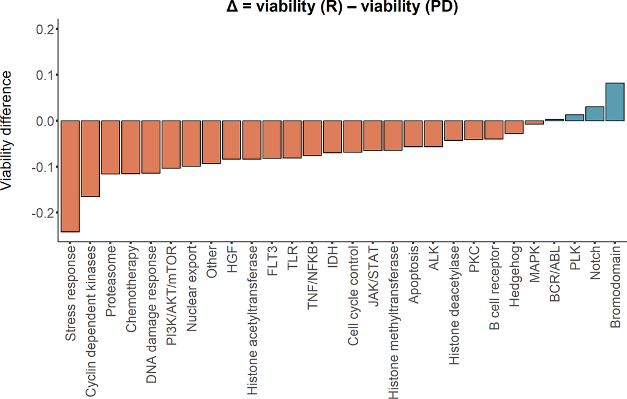

```r
waterfall_plot_Rvs_PD<-ggplot(plotTab, aes(x=Pathway, y=diff_RvsPD, fill=direction)) +
  geom_col(color="black", size=0.7, alpha=0.65, ) +
  scale_fill_manual(values = c("decreased"=red1,"increased"=blue1), name = "Viability")+
  coord_cartesian(ylim = c( min((plotTab$diff_RvsPD)) , 0.2 ) ) +
  ylab("Viability difference\n") + xlab("") +
  theme_figures_x_angle_wo_legend+
  ggtitle("\u0394 = viability (R) – viability (PD)")
waterfall_plot_Rvs_PD
```

```r
# remove(plotTab)
```

## 6.4 6.4 Panel B: Significance in R vs PD comparisons by drug (t-tests).

### 6.4.1 6.4.1 Prepare data

```r
plotTab <- select(df_p_drugAUC, Pathway, name, pval) %>% unique() %>%
  mutate(log10_pval = -log10(pval), significant = ifelse(pval < 0.05,T,F),
         significant = factor(significant, levels=unique(significant) ),
         name = as.character(name))

plotTab[plotTab$name == "Abemaciclib (LY2835219)",]$name <- "Abemaciclib"

# drug_order<-plotTab%>%
#   arrange(pval)%>%
#   select(Pathway)%>%
#   mutate(Pathway=as.character(Pathway))%>%
#   unlist()%>%
#   unique()
```

### 6.4.2 6.4.2 Plot

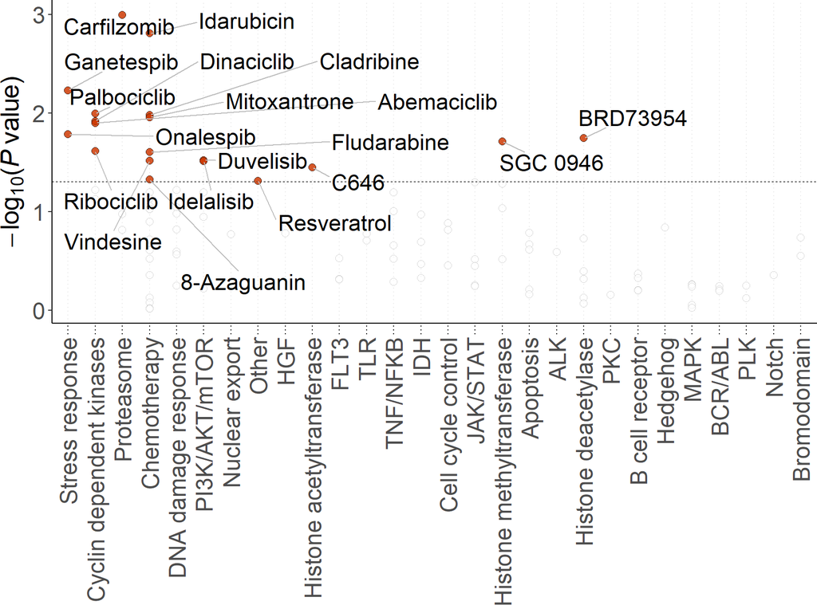

```r
Sign_drugs_RvsPD<-ggplot(plotTab, aes(x=factor(Pathway, levels = Pathway_order), y=log10_pval, fill=significant)) +
  geom_point(shape=21, color ="black", stroke=0.5, size=2.5, alpha=0.6, show.legend = F) +
  scale_fill_manual(values = c("TRUE"=red1, "FALSE"="white")) +
  geom_hline(yintercept = -log10(0.05), linetype="22", col="gray37") +
  gghighlight(significant == T, use_direct_label = F,
              unhighlighted_params = list(fill = NULL, color="gray") ) +
  geom_text_repel(data = filter(plotTab, significant == T), aes(label=name),
                   size=fontsize_small-4, max.overlaps = Inf, min.segment.length = 0.4,
                  box.padding = 0.65, segment.colour="grey")+
  ylab(expression(-log[10]*'('*italic(P)~value*')')) +
  xlab("") +
 theme_classic()+
  theme(plot.title=element_text(size=fontsize+4, hjust = 0.5, face="bold"),
        text=element_text(size=fontsize),
        axis.text.y =element_text(size=fontsize),
        axis.text.x =element_text(size=fontsize, angle=90, vjust=0.5, hjust=1),
        axis.title.y =element_text(size=fontsize+2),
        axis.title.x =element_text(size=fontsize+2),
        panel.grid.major.x = element_line(size = 0.5,linetype = "13"),
        axis.ticks.x = element_line(size = 0.5, color = "black", linetype = "13"),
        axis.ticks.length.x = unit(0.3, "cm"),
        legend.position = "none")
Sign_drugs_RvsPD
```

```r
# remove(plotTab)
```

## 6.5 Plot Figure S7

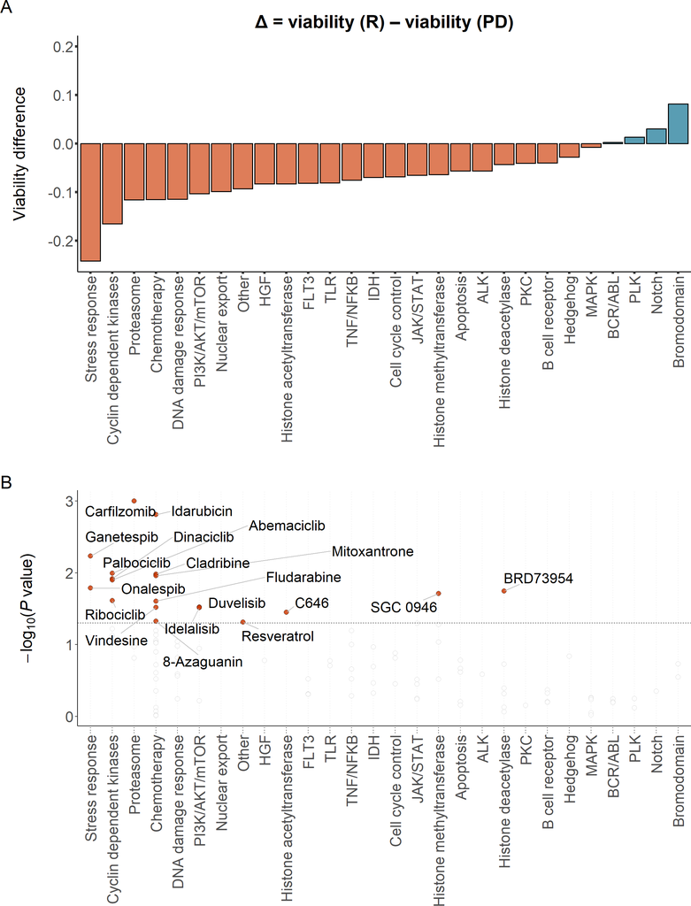

```r
waterfall_plot_Rvs_PD+
  Sign_drugs_RvsPD+
  plot_layout(ncol=1)+
  plot_annotation( tag_levels = "A"  )
```

```r
ggsave(path=(paste0("../../docs/")), filename = "Figure_S7.pdf", device = cairo_pdf)
```

## 6.6 6.5 Panel C: Dose-response curves and AUC box-plots for exemplary drugs.

**Selected drugs**

```r
example_drugs <- c("Idarubicin", "Vindesine")
```

**Fit curves**

```r
#data storage
df_smooth_curve <- data.frame()

for ( drugname in example_drugs ){
  #prepare data
  df <- filter(df_chemo, name == drugname ) %>%
    select(patientID, response, name, concentration, normVal) %>%
    arrange( desc(response) ) %>% mutate(response = factor(response, levels = unique(response)))
  #call fun
  res <- suppressWarnings(fit_log_curve(df, drugname))
  #store data (1k predicted viability values for plotting a smooth curve)
  df_smooth_curve <- rbind(df_smooth_curve, res[[5]] )
}
```

**prepare data**

```r
plotTab <- select(df_chemo, Pathway, name, patientID, response, concentration, normVal) %>%
  #PD points on top
  arrange( desc(response) ) %>% mutate(response = factor(response, levels=unique(response)))
```

**make figs**

```r
plotList_DResp <- lapply( example_drugs ,function(drugname){
  #plot values: real with dots, predicted with line
  plotTabSub <- filter(plotTab, name == drugname)
  ciTab <- group_by(plotTabSub, response, concentration) %>%
      summarise(meanVal = mean(normVal), sdVal = sd(normVal), n=length(patientID)) %>%
      mutate(se = sdVal/sqrt(n), ci = 1.96*se)
  p <- ggplot(NULL,aes(color=response, fill=response)) +
    geom_line(data = df_smooth_curve[df_smooth_curve$name == drugname,],
              aes(x= concentration, y= viab_pred), size=1) +
    geom_point(data = plotTabSub ,
               aes(x= concentration, y=normVal),
               shape = 21, size=3.5, alpha = 0.3, color="black") +
    geom_errorbar(data = ciTab, aes(x=concentration, y=meanVal, ymax = meanVal + ci, ymin=meanVal-ci),
                  width=0.1, size=1) +
    scale_color_manual(values = c("R" = blue1, "PD"=red2)) +
    scale_fill_manual(values = c("R" = blue2, "PD"=red1)) +

    coord_cartesian(ylim = c(0,1.5)) +
    scale_x_continuous(trans='log10') +

    labs(title =  paste0("",drugname) )+
    xlab(expression("Concentration"~(mu*M))) + ylab("Viability") +
    guides(fill="none", color="none") +
    theme_classic()+
    theme(plot.title=element_text(size=fontsize+4, hjust = 0, face="bold"),
        text=element_text(size=fontsize),
        axis.text.y =element_text(size=fontsize),
        axis.text.x =element_text(size=fontsize),
        axis.title.y =element_text(size=fontsize+2),
        axis.title.x =element_text(size=fontsize+2),
        axis.line = element_blank(),
        panel.border = element_rect(size=1.5, fill = NA),
        axis.ticks = element_line(size=1.5),
        legend.text = element_text(size=fontsize),
        legend.title = element_text(size=fontsize+2))
  p
})
plotList_box <- lapply( example_drugs ,function(drugname){
  #get the df
  df_plot <- filter(df_p_drugAUC, name == drugname)
  pval <- formatC(unique(df_plot$pval), digits = 2)
  pText <- bquote(italic("P")~"="~.(pval))

  #make plot
  p <- ggplot(df_plot, aes(x=response, y=AUC)) +
    geom_boxplot(aes(fill = response), width = 0.8, size=0.8, alpha = 0.85,
                 color = "black", outlier.shape = NA) +
    scale_fill_manual(values = c("PD"=red1,"R"=blue1) ) +
    geom_beeswarm(aes(color = response),cex=3, dodge.width=0.8, shape=21,
                  fill="slategray4", size=4, alpha= 0.7) +
    ggplot2::annotate(geom = "text", label = pText, x=2.0, y=1.3, parse = FALSE, hjust=0)+
    scale_color_manual(values = c("black", "black") ) +
    geom_hline(yintercept = 1, linetype="22", col="gray30", size=0.7) +
    coord_cartesian(ylim = c(0,1.5)) +
    labs(title= "" ) +
    xlab(expression(paste(italic("in vivo")," response"))) +
    ylab("Viability (AUC)") +
    guides(color="none", fill="none") +
    theme_classic()+
    theme(plot.title=element_text(size=fontsize+4, hjust = 0, face="bold"),
        text=element_text(size=fontsize),
        axis.text.y =element_text(size=fontsize),
        axis.text.x =element_text(size=fontsize),
        axis.title.y =element_text(size=fontsize+2),
        axis.title.x =element_text(size=fontsize+2),
        axis.line = element_blank(),
        panel.border = element_rect(size=1.5, fill = NA),
        axis.ticks = element_line(size=1.5),
        legend.text = element_text(size=fontsize),
        legend.title = element_text(size=fontsize+2))

  return( p )
})

#merge both plot lists
plotList <- c(rbind(plotList_DResp, plotList_box))
```

**get legend**

**plot figs**

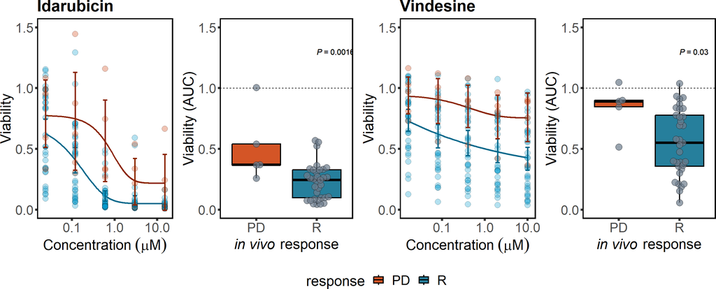

```r
# plot_3C_tmp<-plot_grid(plotlist = plotList, nrow=4, ncol=2, rel_widths = c(1, 0.8))
#
#
# plot_3C<-plot_grid(plot_3C_tmp, legend_3C, ncol = 1, rel_heights = c(1, .1))
# plot_3C



design<-"
A#B#C#D
EEEEEEE
"

plot_3C<-
plotList[[1]]+
plotList[[2]]+
plotList[[3]]+
plotList[[4]]+
# plotList[[5]]+
# plotList[[6]]+
# plotList[[7]]+
# plotList[[8]]+
  legend_3C+

  plot_layout(design = design, widths = c(1,0.01,0.98,0.01,1,0.01,0.98), heights = c(1,0.2))

plot_3C
```

```r
#remove(df, df_smooth_curve, plotList, plotList_box, plotList_DResp, plotTab, res, legend_3C)
```

# 7 7 Elastic net regression model

```r
# Set a seed for reproducibility
set.seed(20191120)


#Modify drug names for formula function
tmp <- df_drugs %>% mutate(Drug = as.character(Drug), Drug = case_when(Drug == "8-Azaguanin" ~ "Azaguanin", Drug == "Azacytidine (Vidaza)" ~ "Vidaza",Drug == "Decitabine (Dacogen)" ~ "Decitabine", TRUE ~ Drug))
chemotherapies <- (tmp %>% filter(pathway == "Chemotherapy", !(Drug %in% c("Cisplatin", "Cyclophasphamide"))))$Drug

lasso_analysis_set <- data_all %>%
  # filter only chemopatients
  filter(chemo_pat==TRUE)%>%
  filter(!is.na(Treatment_type), Treatment_type!="na", Resp_protocol %in% c("R", "PD"))%>%
  # filter only patients with an evaluable in vivo response
  filter(Response_not_evaluable!="1")%>%
  # filter patients only with both plates available
  filter(Count_plates==2) %>%
  #restrict to chemotherapies, modify drug names
  mutate(Drug = as.character(Drug)) %>%
  mutate(Drug = case_when(Drug == "8-Azaguanin" ~ "Azaguanin", Drug == "Azacytidine (Vidaza)" ~ "Vidaza",Drug == "Decitabine (Dacogen)" ~ "Decitabine", TRUE ~ Drug)) %>%
  filter(Drug %in% chemotherapies)  %>%
  select(patientID, Drug, AUC, Resp_protocol)

#Transform data to wide format for regression analysis
lasso_analysis_set <- lasso_analysis_set %>% tidyr::spread("Drug", AUC)

formula <- as.formula(paste("Resp_protocol ~ ", paste(chemotherapies, collapse = " + "), sep = ""))

x.bestr <- model.matrix(formula, lasso_analysis_set)
y.bestr <- lasso_analysis_set$Resp_protocol

lasso.bestr.models <- repeated_glmnet(X = x.bestr, Y = y.bestr, alpha = 0.3, nlambda = 100, nfolds = 3)

list.results.bestr <- give_repeated_lasso_results(lasso.bestr.models, type.measure ="auc")

#
# print.xtable(xtable(list.results.bestr[[1]]), include.rownames=FALSE, table.placement = "ht", type = "html")
# write.csv(list.results.bestr[[1]], file = "elastic_net_results.csv")
knitr::kable(list.results.bestr[[1]][,-1])
```

|  | medianOR | Proportion_selected | median_AUROC |
| --- | --- | --- | --- |
| Vincristine | 0.959 | 1.000 | 0.847 |
| Idarubicin | 0.967 | 0.987 | 0.847 |
| Vindesine | 0.971 | 0.985 | 0.847 |
| Mitoxantrone | 0.974 | 0.969 | 0.847 |
| Cladribine | 0.973 | 0.884 | 0.844 |
| Fludarabine | 0.976 | 0.532 | 0.833 |
| Azaguanin | 0.965 | 0.445 | 0.836 |
| Etoposide | 0.973 | 0.445 | 0.836 |
| Thioguanin | 0.933 | 0.389 | 0.839 |
| Pentostatin | 1.120 | 0.262 | 0.844 |
| Bendamustine | 0.941 | 0.249 | 0.847 |
| Pralatrexate | 0.921 | 0.249 | 0.847 |
| Nelarabine | 1.009 | 0.150 | 0.861 |
| Clofarabine | 1.141 | 0.145 | 0.865 |
| Daunorubicin | 1.128 | 0.138 | 0.867 |
| Cytarabine | 1.074 | 0.122 | 0.867 |
| Doxorubicin | 1.031 | 0.112 | 0.867 |
| Chlorambucil | 1.010 | 0.107 | 0.876 |
| Vidaza | 1.012 | 0.101 | 0.867 |
| Decitabine | 1.069 | 0.014 | 0.877 |
| (Intercept) | 1.000 | 0.000 | 0.500 |

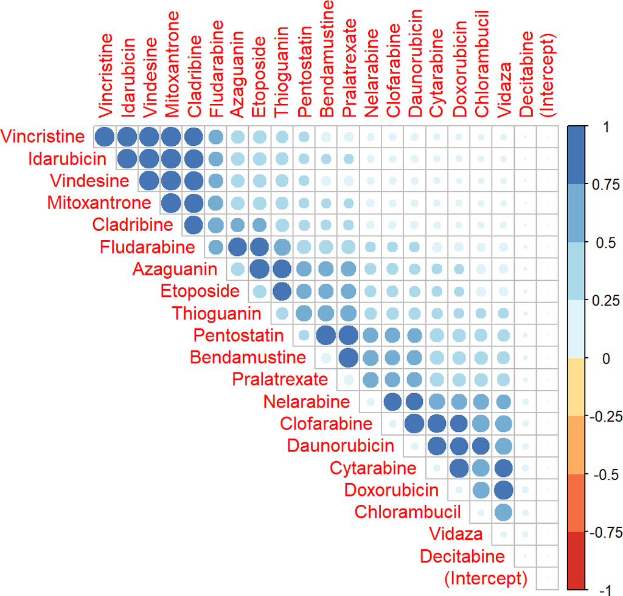

```r
tabforFig3D<-list.results.bestr[[1]][1:6,-1]
colnames(tabforFig3D)<-c("Median OR", "Selected Proportion", "Median AUROC")

corrplot(list.results.bestr[[2]], type="upper", col=brewer.pal(n=8, name="RdYlBu"))
```

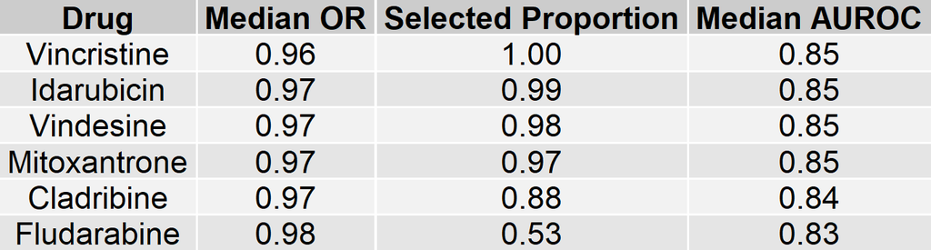

```r
tabforFig3D<-tabforFig3D %>%
  mutate(`Median OR`=round(`Median OR`,2),
         `Selected Proportion`=round(`Selected Proportion`,2),
         `Median AUROC`=round(`Median AUROC`,2))

Fig3D<-  ggplot(rownames_to_column(tabforFig3D, var = "Drug"))+
   annotate(geom = "table", size=fontsize_small-4, x = 0,y = 0, label = list(cbind(rownames_to_column(tabforFig3D, var = "Drug"))))+
    theme_void()

Fig3D
```

# 8 8 EFS analyses

## 8.1 8.1 Drugs which were relevant in elastic net model

```r
tmp<-data_all%>%
  # filter only chemopatients
  filter(chemo_pat==TRUE)%>%
  filter(!is.na(Treatment_type), Treatment_type!="na")%>%
  # filter only patients with an evaluable in vivo response
  filter(Response_not_evaluable!="1")%>%
  # filter only relevant drugs from elastic net
  filter(Pathway=="Chemotherapy")%>%filter(Drug=="Vindesine" | Drug=="Idarubicin" |  Drug=="Mitoxantrone" |Drug=="Vincristine" |Drug=="Cladribine"|Drug=="Fludarabine")%>%
  # filter patients only with both plates available (to be consistent with elastic net model)
  filter(Count_plates==2)

tmp$Drug<- as.factor(tmp$Drug)

tmp<-tmp%>%select(patientID, Drug, AUC, Event, time_EFS)

# AUC is scaled such that a unit change of the regressor corresponds to 10% change in cell viability.
tmp<-tmp%>%mutate(AUC_percent=AUC*100)
tmp<-tmp%>%mutate(AUC_10percent=AUC*100/10)

# loop to calculate HR + 95%CI + p for each drug
result<-data.frame(matrix(nrow =1, ncol=5))
colnames(result)<- c("drug", "HR",  "lower", "upper","p_value_cox")

for(i in levels(tmp$Drug)){
tmp2<-tmp%>%filter(Drug==i)
cox<-coxph(Surv(time_EFS/365, Event) ~ (AUC_10percent),
               data=tmp2)
cox_sum<-summary(cox)


result[i, 1] <-i
result[i, 2] <-cox_sum[["coefficients"]][, "exp(coef)"]
result[i, 3] <-cox_sum[["conf.int"]][, "lower .95"]
result[i, 4] <-cox_sum[["conf.int"]][, "upper .95"]
result[i, 5] <-cox_sum[["coefficients"]][, "Pr(>|z|)"]
}

result<-result[-which(rownames(result)==1),]
tablefig3D<-result[-which(rownames(result)==1),]

# plot results
knitr::kable(tablefig3D)
```

| drug | HR | lower | upper | p_value_cox |
| --- | --- | --- | --- | --- |

```r
remove(tmp, tmp2, cox, cox_sum)
```

**Plotting of Forest plot**

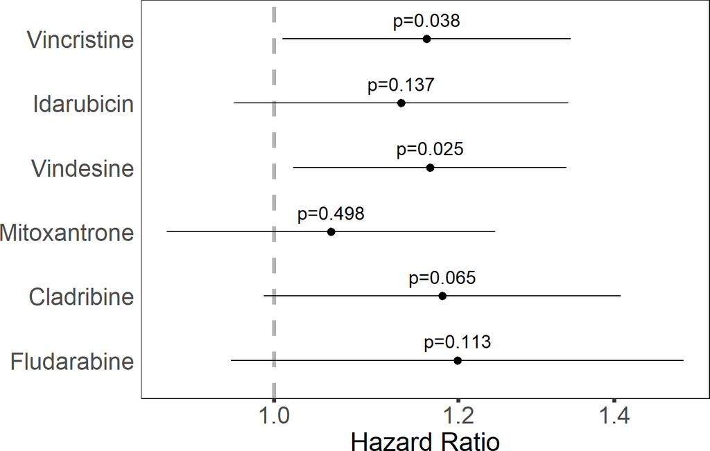

```r
result$drug<-factor(result$drug, levels=rev(c("Vincristine", "Idarubicin","Vindesine", "Mitoxantrone", "Cladribine", "Fludarabine")))

plot_3E<-ggplot(data=result ,aes(x=drug, y=HR, ymin=lower, ymax=upper,
                     )) +  geom_pointrange() +
     # scale_x_discrete(limits=result$drug,breaks=rev(levels(result$drug)), name="")+
     scale_y_log10() +
  xlab("")+
     scale_color_manual(values="black", name="")+
     coord_flip() +
     geom_hline(aes(yintercept=1), colour="black", size=1.5,
                linetype="dashed", alpha=0.3)  +
     # annotate("text", x = 1:nrow(result)+0.2, y = result$HR+0.003,
     #         label = ifelse( result$p_value_cox<0.001, paste0("p<","0.001"),
     #            paste0("p=", round(result$p_value_cox,3) ) ), size=fontsize_small-4)+
  geom_text(nudge_x =.3, label=paste0("p=", round(result$p_value_cox,3)), size=fontsize_small-5)+
    theme(panel.grid.minor = element_blank(),
        text=element_text(size=fontsize),
        axis.text.y =element_text(size=fontsize),
        axis.text.x =element_text(size=fontsize),
        axis.title.y =element_text(size=fontsize+2),
        axis.title.x =element_text(size=fontsize+2),
        legend.position = "none",
        panel.background = element_rect(fill = "white", color="black"),
        panel.grid.major = element_blank(),
        axis.ticks.x = element_line(size=1.5),
        axis.ticks.y = element_blank())+
  ylab("Hazard Ratio")

plot_3E
```

```r
# remove(result)
```

## 8.2 8.2 EFS-KM curves for selected drugs

### 8.2.1 8.2.1 Vindesine ~ EFS in chemogroup

```r
x<-"Vindesine"

# prepare data
tmp<-data_all%>%
  # filter only chemopatients
  filter(chemo_pat==TRUE)%>%
  filter(!is.na(Treatment_type), Treatment_type!="na")%>%
  # filter only patients with an evaluable in vivo response
  filter(Response_not_evaluable!="1")%>%
  # filter only relevant drugs from elastic net
  filter(Pathway=="Chemotherapy")%>%filter(Drug=="Vindesine" | Drug=="Idarubicin" |  Drug=="Mitoxantrone" |Drug=="Vincristine" |Drug=="Cladribine"|Drug=="Fludarabine")%>%
  # filter patients only with both plates available (to be consistent with elastic net model)
  filter(Count_plates==2)%>%
  filter(Drug==x)

# perform maximally selected log rank statistics
m_EFS<-maxstat.test(Surv(time_EFS/365, Event) ~ AUC, data=tmp,
    smethod="LogRank", pmethod="Lau94", minprop = 0.2,

                                maxprop = 0.8)
m_EFS
```

```
##
## Maximally selected LogRank statistics using Lau94
##
## data:  Surv(time_EFS/365, Event) by AUC
## M = 2, p-value = 0.1
## sample estimates:
## estimated cutpoint
##              0.766
```

```r
# divide patients into two groups based on cutpoint
tmp$drug_sensitive<-tmp$AUC<=m_EFS$estimate

#  perform survival analyses
fit_EFS <- survfit(Surv(time_EFS/365, Event) ~ drug_sensitive, data=tmp)
surv_median(fit_EFS)
```

```
##                 strata median  lower upper
## 1 drug_sensitive=FALSE 0.0932 0.0521 0.392
## 2  drug_sensitive=TRUE 0.4849 0.2301    NA
```

```r
survdiff(Surv(time_EFS/365, Event) ~ drug_sensitive, data=tmp)
```

```
## Call:
## survdiff(formula = Surv(time_EFS/365, Event) ~ drug_sensitive,
##     data = tmp)
##
##                       N Observed Expected (O-E)^2/E (O-E)^2/V
## drug_sensitive=FALSE 15       14     7.29      6.19      8.44
## drug_sensitive=TRUE  28       19    25.71      1.75      8.44
##
##  Chisq= 8.4  on 1 degrees of freedom, p= 0.004
```

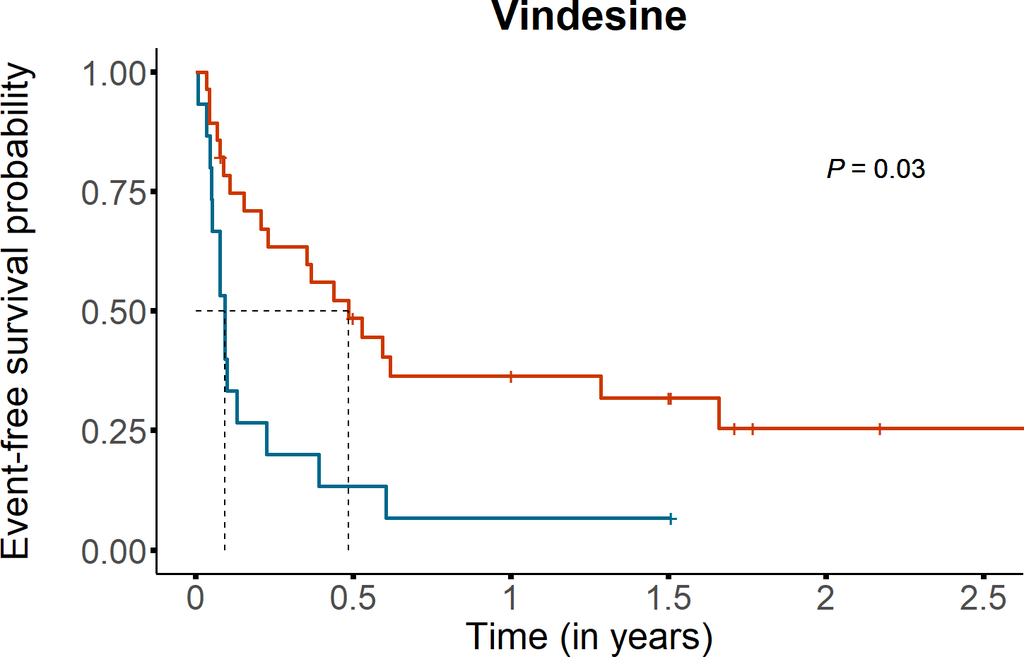

```r
# annotate p-value
pval <- filter(result, drug == "Vindesine")$p_value_cox
pval <- formatNum(pval, digits = 1)
pAnno <- bquote(italic("P")~"="~.(pval))

# plot KM curve
ggsurvplot_EFS_Vind<-ggsurvplot(fit_EFS,  conf.int =FALSE, risk.table = TRUE, pval = FALSE,
           title="Vindesine",
           xlab ="Time (in years)",
           xlim = c(0, 2.5),
          break.time.by=0.5,
           ylab ="\nEvent-free survival probability\n",
           surv.median.line = "hv",
           tables.theme=clean_theme(),
           legend="none",
           legend.title=(""),
           legend.labs=c("less sensitive", "sensitive"),
           palette = c(blue1, red1),
           ggtheme=theme_figures)

plot_EFS_Vind <- ggsurvplot_EFS_Vind$plot + ggplot2::annotate("text",label=pAnno, x = 2, y=0.8, hjust =0, size=5)

plot_EFS_Vind
```

```r
remove(tmp, x, m_EFS, fit_EFS, ggsurvplot_EFS_Vind)
```

### 8.2.2 8.2.2 Vincristine ~ EFS in chemogroup

```r
x<-"Vincristine"

# prepare data
tmp<-data_all%>%
  # filter only chemopatients
  filter(chemo_pat==TRUE)%>%
  filter(!is.na(Treatment_type), Treatment_type!="na")%>%
  # filter only patients with an evaluable in vivo response
  filter(Response_not_evaluable!="1")%>%
  # filter only relevant drugs from elastic net
  filter(Pathway=="Chemotherapy")%>%filter(Drug=="Vindesine" | Drug=="Idarubicin" |  Drug=="Mitoxantrone" |Drug=="Vincristine" |Drug=="Cladribine"|Drug=="Fludarabine")%>%
  # filter patients only with both plates available (to be consistent with elastic net model)
  filter(Count_plates==2)%>%
  filter(Drug==x)

# perform maximally selected log rank statistics
m_EFS<-maxstat.test(Surv(time_EFS/365, Event) ~ AUC, data=tmp,
    smethod="LogRank", pmethod="Lau94", minprop = 0.2,
                             maxprop = 0.8)
m_EFS
```

```
##
## Maximally selected LogRank statistics using Lau94
##
## data:  Surv(time_EFS/365, Event) by AUC
## M = 2, p-value = 0.3
## sample estimates:
## estimated cutpoint
##              0.722
```

```r
# divide patients into two groups based on cutpoint
tmp$drug_sensitive<-tmp$AUC<=m_EFS$estimate

#  perform survival analyses
fit_EFS <- survfit(Surv(time_EFS/365, Event) ~ drug_sensitive, data=tmp)
surv_median(fit_EFS)
```

```
##                 strata median  lower upper
## 1 drug_sensitive=FALSE 0.0932 0.0767 0.603
## 2  drug_sensitive=TRUE 0.4849 0.2082    NA
```

```r
survdiff(Surv(time_EFS/365, Event) ~ drug_sensitive, data=tmp)
```

```
## Call:
## survdiff(formula = Surv(time_EFS/365, Event) ~ drug_sensitive,
##     data = tmp)
##
##                       N Observed Expected (O-E)^2/E (O-E)^2/V
## drug_sensitive=FALSE 14       13     7.22      4.64      6.29
## drug_sensitive=TRUE  29       20    25.78      1.30      6.29
##
##  Chisq= 6.3  on 1 degrees of freedom, p= 0.01
```

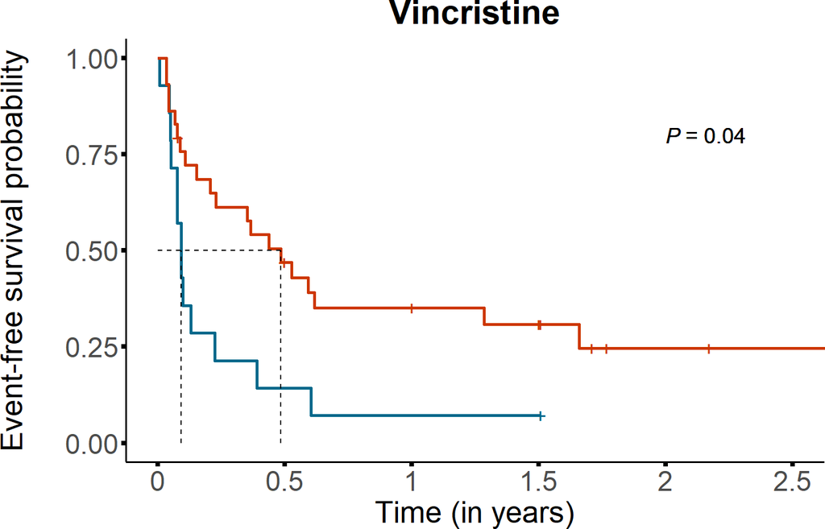

```r
# annotate p-value
pval <- filter(result, drug == "Vincristine")$p_value_cox
pval <- formatNum(pval, digits = 1)
pAnno <- bquote(italic("P")~"="~.(pval))


# plot KM curve
ggsurvplot_EFS_Vinc<-ggsurvplot(fit_EFS,  conf.int =FALSE, risk.table = TRUE, pval = FALSE,
           title="Vincristine",
           xlab ="Time (in years)",
           xlim = c(0, 2.5),
           break.time.by=0.5,
           ylab ="\nEvent-free survival probability\n",
           surv.median.line = "hv",
           tables.theme=clean_theme(),
           legend="none",
           legend.title=(""),
           legend.labs=c("less sensitive", "sensitive"),
           palette = c( blue1, red1),
           ggtheme=theme_figures)

plot_EFS_Vinc<-ggsurvplot_EFS_Vinc$plot + ggplot2::annotate("text",label=pAnno, x = 2, y=0.8, hjust =0, size=5)
plot_EFS_Vinc
```

```r
remove(tmp, x, m_EFS, fit_EFS, ggsurvplot_EFS_Vinc)
```

### 8.2.3 8.2.3 Cladribine ~ EFS in chemogroup

```r
x<-"Cladribine"

# prepare data
tmp<-data_all%>%
  # filter only chemopatients
  filter(chemo_pat==TRUE)%>%
  filter(!is.na(Treatment_type), Treatment_type!="na")%>%
  # filter only patients with an evaluable in vivo response
  filter(Response_not_evaluable!="1")%>%
  # filter only relevant drugs from elastic net
  filter(Pathway=="Chemotherapy")%>%filter(Drug=="Vindesine" | Drug=="Idarubicin" |  Drug=="Mitoxantrone" |Drug=="Vincristine" |Drug=="Cladribine"|Drug=="Fludarabine")%>%
  # filter patients only with both plates available (to be consistent with elastic net model)
  filter(Count_plates==2)%>%
  filter(Drug==x)

# perform maximally selected log rank statistics
m_EFS<-maxstat.test(Surv(time_EFS/365, Event) ~ AUC, data=tmp,
    smethod="LogRank", pmethod="Lau94", minprop = 0.2,
                             maxprop = 0.8)
m_EFS
```

```
##
## Maximally selected LogRank statistics using Lau94
##
## data:  Surv(time_EFS/365, Event) by AUC
## M = 2, p-value = 0.5
## sample estimates:
## estimated cutpoint
##              0.548
```

```r
# divide patients into two groups based on cutpoint
tmp$drug_sensitive<-tmp$AUC<=m_EFS$estimate

#  perform survival analyses
fit_EFS <- survfit(Surv(time_EFS/365, Event) ~ drug_sensitive, data=tmp)
surv_median(fit_EFS)
```

```
##                 strata median  lower upper
## 1 drug_sensitive=FALSE  0.132 0.0438    NA
## 2  drug_sensitive=TRUE  0.353 0.0986  1.66
```

```r
survdiff(Surv(time_EFS/365, Event) ~ drug_sensitive, data=tmp)
```

```
## Call:
## survdiff(formula = Surv(time_EFS/365, Event) ~ drug_sensitive,
##     data = tmp)
##
##                       N Observed Expected (O-E)^2/E (O-E)^2/V
## drug_sensitive=FALSE  9        9     4.68     3.982      4.92
## drug_sensitive=TRUE  34       24    28.32     0.658      4.92
##
##  Chisq= 4.9  on 1 degrees of freedom, p= 0.03
```

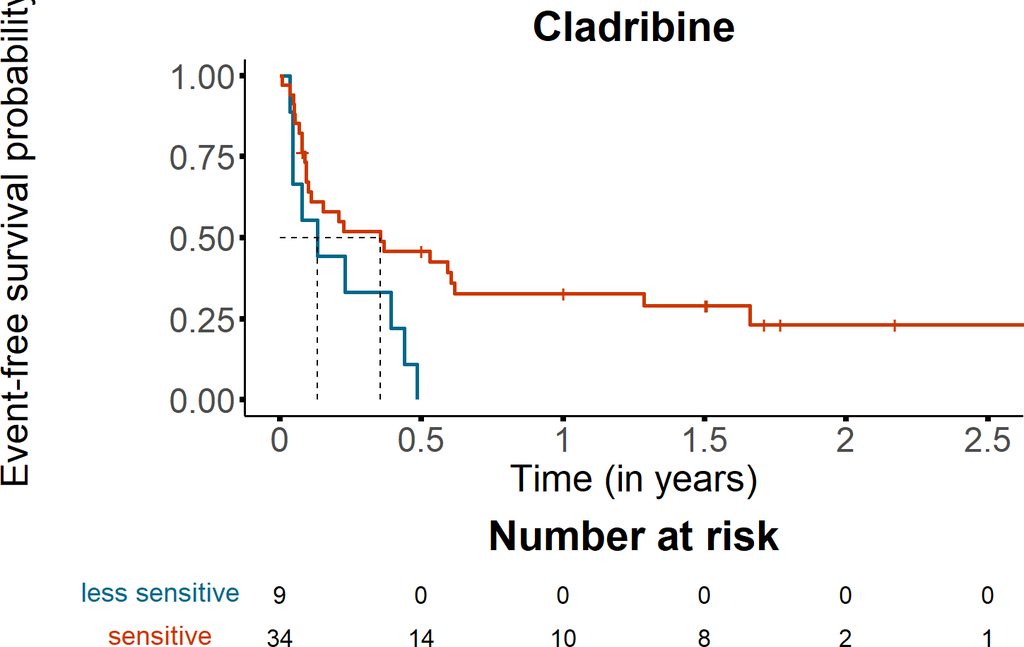

```r
# plot KM curve
ggsurvplot_EFS_Clad<-ggsurvplot(fit_EFS,  conf.int =FALSE, risk.table = TRUE, pval = FALSE,
           title="Cladribine",
           xlab ="Time (in years)",
           xlim = c(0, 2.5),
           break.time.by=0.5,
           ylab ="\nEvent-free survival probability\n",
           surv.median.line = "hv",
           tables.theme=clean_theme(),
           legend="none",
           legend.title=(""),
           legend.labs=c("less sensitive", "sensitive"),
           palette = c( blue1, red1),
           ggtheme=theme_figures)

ggsurvplot_EFS_Clad
```

```r
plot_EFS_Clad<-ggsurvplot_EFS_Clad$plot

remove(tmp, x, m_EFS, fit_EFS, ggsurvplot_EFS_Clad)
```

### 8.2.4 8.2.4 Build plot with KM curves of selected drugs (Figure 3F)

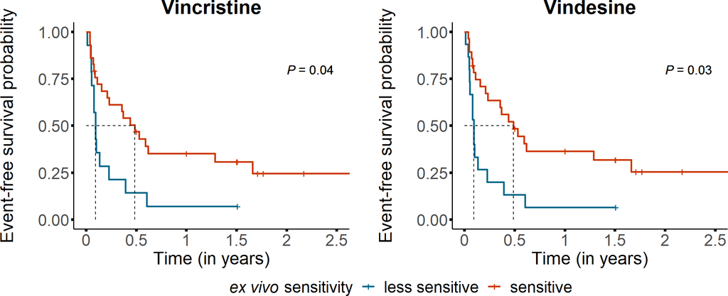

```r
design1<-"
AB
DD
"

plot_3F<-
  plot_EFS_Vinc+
  plot_EFS_Vind+
  # plot_EFS_Clad+
  legend_3F+
  plot_layout(design=design1, heights = c(1,0.15))
plot_3F
```

```r
# remove(plot_EFS_Clad, plot_EFS_Vinc, plot_EFS_Vind, legend_3F)
```

# 9 9 Plot Figure 3

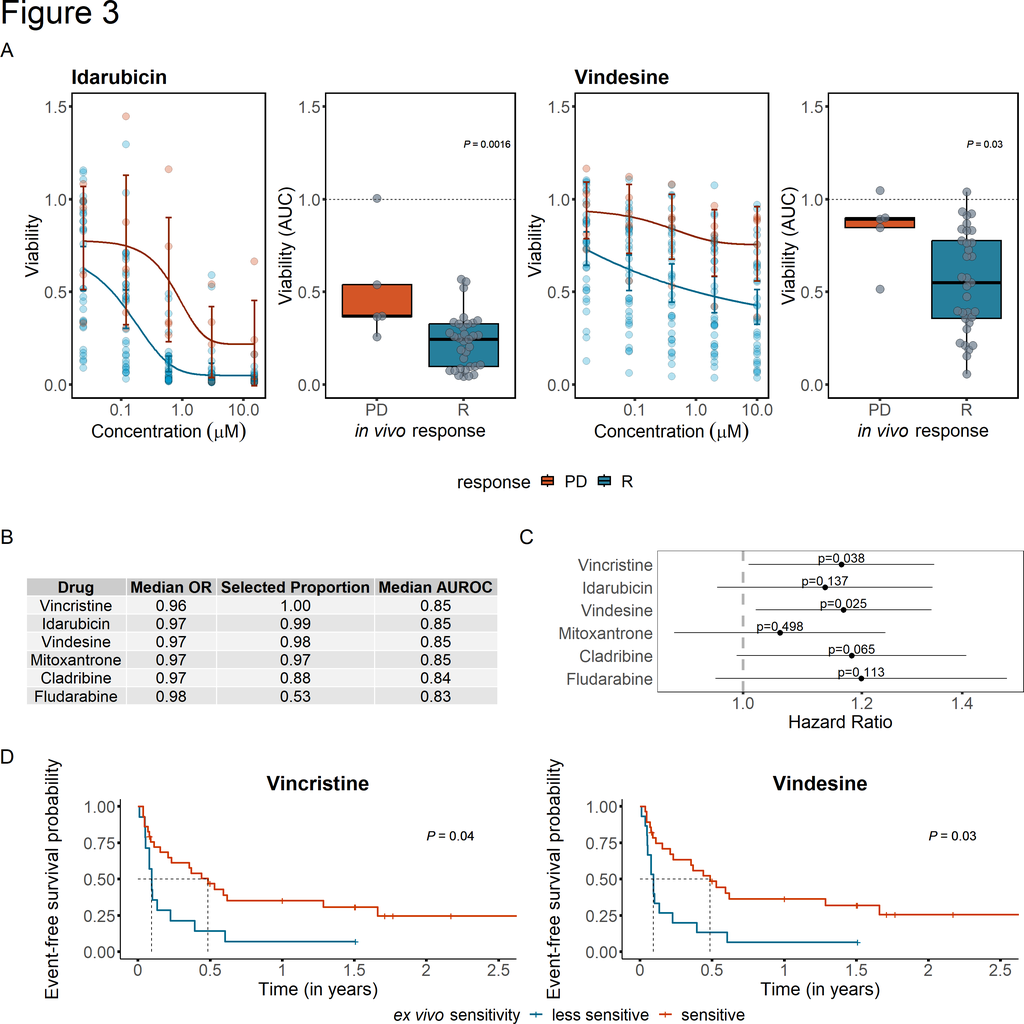

```r
library("Cairo")


design<-"
AAAA
BBCC
DDDD
"
tp<-theme()

wrap_elements(plot_3C) + wrap_elements(Fig3D) + wrap_elements(plot_3E) + wrap_elements(plot_3F) +
    plot_layout(design=design, widths = c(1,1,.2,1.8), heights = c(1.2,.5,.7)) +
    plot_annotation(title = "Figure 3", tag_levels = "A") &  theme(title = element_text(size=30), plot.tag = element_text(size=22))
```

```r
ggsave(path=(paste0("../../docs/")), filename = "Figure_3.svg")
ggsave(path=(paste0("../../docs/")), filename = "Figure_3.pdf", device = cairo_pdf)
```

# 10 10 Burkitt lymphoma patient example (S005)

Burkitt Lymphoma: pretreatment with GMALL, during study treatment with R-DHAP –> PD with new liver lesions, then salvage treatment with MTX –> CR

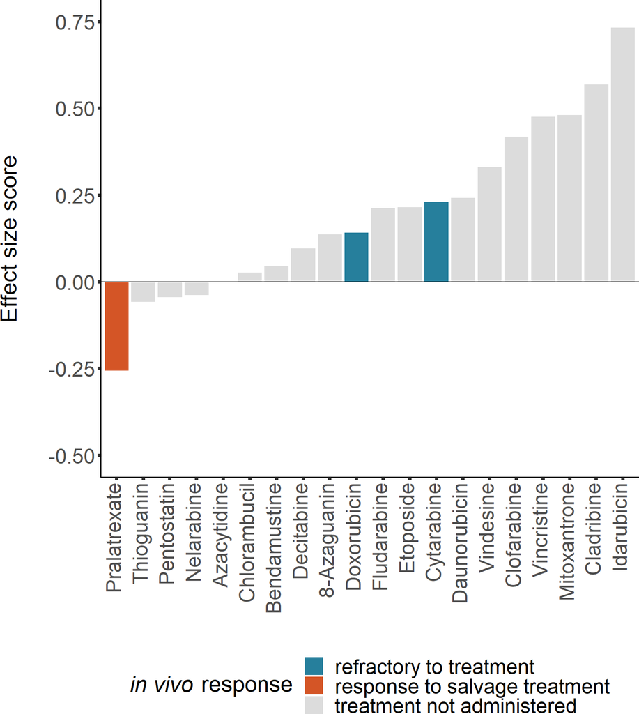

```r
# Prepare data: filter only for patient S005, label specific drugs which the patient had received to use these for colorcoding later in the plot
df_S005<-data_all%>%filter(patientID=="S005")%>%mutate(Drug_coding=case_when((Drug=="Doxorubicin" | Drug=="Cytarabine" ) ~ "refractory to treatment", Drug=="Pralatrexate" ~ "response to salvage treatment", (Drug!="Doxorubicin" &Drug!="Cytarabine" & Drug!="Pralatrexate") ~ "treatment not administered"))

# rename Drugs which includes the brand name in the original drug list
df_S005<-df_S005%>%mutate(Drug=ifelse(Drug=="Azacytidine (Vidaza)", "Azacytidine", Drug))
df_S005<-df_S005%>%mutate(Drug=ifelse(Drug=="Decitabine (Dacogen)", "Decitabine", Drug))

# define theme for figure
theme_figures_S005<- theme_classic()+
  theme(plot.title=element_text(size=fontsize+4, hjust = 0.5, face="bold"),
        text=element_text(size=fontsize),
        axis.text.y =element_text(size=fontsize),
         axis.text.x =element_text(size=fontsize, angle=45, vjust=1, hjust=1),
        axis.title.y =element_text(size=fontsize+2),
        axis.title.x =element_text(size=fontsize+2),
        axis.line = element_line(size=0.6),
        axis.ticks = element_line(size=1.5),
        legend.text = element_text(size=fontsize),
        legend.title = element_text(size=fontsize+2),
        legend.position ="bottom")


plot_S005_ESS<-df_S005%>%filter(Pathway=="Chemotherapy")%>%
  ggplot(aes(x=reorder(Drug, ESS_AUC), y=ESS_AUC, fill=Drug_coding)) +
  geom_bar(stat="identity", alpha=0.85)+
  scale_x_discrete(name="")+
  scale_y_continuous(name="Effect size score\n", limits=c(-0.5, 0.75))+
  geom_hline(yintercept = 0)+
  scale_fill_manual(name=expression(paste(italic("in vivo")," response")), values=c(blue1, red1, "gray84"))+
  theme_figures_S005+
  theme(axis.text.x =element_text(angle=90, vjust=0.25))+
  guides(fill = guide_legend(nrow = 3))

plot_S005_ESS
```

```r
ggsave( path=(paste0(filepath,"docs")), filename = "Figure_S9.svg")
remove(df_S005, plot_S005_ESS, theme_figures_S005)
```

# 11 11 CLL patients with venetoclax and ibrutinib treatment

## 11.1 11.1 Ibrutinib

```r
theme_CLL_ibr<- theme_classic()+
  theme(plot.title=element_text(size=fontsize+4, hjust = 0.5, face="bold"),
        text=element_text(size=fontsize),
        axis.text.y =element_text(size=fontsize),
         axis.text.x =element_text(size=fontsize, angle=45, vjust=1, hjust=1),
        axis.title.y =element_text(size=fontsize+2),
        axis.title.x =element_text(size=fontsize+2),
        axis.line = element_line(size=0.6),
        axis.ticks = element_line(size=1.5),
        legend.text = element_text(size=fontsize),
        legend.title = element_text(size=fontsize+2),
        legend.position = c(0.8, 0.2))

# prepare CLL ibrutinib dataset
df_CLL_ibr<-data_all%>%mutate(Ibrutinib=ifelse(grepl("Ibrutinib", treatment_spec), 1, 0))
df_CLL_ibr<-df_CLL_ibr%>%filter(Drug=="Ibrutinib")%>%filter(Ibrutinib==1)%>%filter(diagnosis=="CLL")%>%filter(Response_not_evaluable==0)
df_CLL_ibr$Resp_protocol <-factor(df_CLL_ibr$Resp_protocol, levels=c("R", "SD"),
                       labels=c("response","stable disease")) # patients had only R or SD, no patients with PD


plot_ibr<-df_CLL_ibr%>%ggplot(aes(x=reorder(patientID, -ES_AUC), y=-ES_AUC, fill=Resp_protocol)) +
  geom_bar(stat="identity", alpha=0.75)+
  scale_x_discrete(name="\nCLL patients")+
  scale_y_continuous(name=expression(paste("Effect size (",italic("ex vivo"),")")), limits=c(-0.4, 0), breaks=c( -0.4, -0.2, 0), labels=c( 0.4, 0.2, 0))+
  geom_hline(yintercept = 0)+
  scale_fill_manual(values=c( blue1, red1), name=expression(paste(italic("in vivo")," response")))+
   ggtitle("Ibrutinib")+
  theme_CLL_ibr
# plot_ibr

remove(df_CLL_ibr, theme_CLL_ibr)
```

## 11.2 11.2 Venetoclax

```r
# prepare CLL venetoclax dataset
df_CLL_ven<-data_all%>%mutate(Venetoclax=ifelse(grepl("Venetoclax", treatment_spec), 1, 0))
df_CLL_ven<-df_CLL_ven%>%filter(Drug=="Venetoclax")%>%filter(Venetoclax==1)%>%filter(diagnosis=="CLL")%>%filter(Response_not_evaluable==0)
df_CLL_ven$Resp_protocol<-factor(df_CLL_ven$Resp_protocol, levels=c("R"),
                       labels=c("response        ")) # all patients had a R


plot_ven<-df_CLL_ven%>%ggplot(aes(x=reorder(patientID, -ES_AUC), y=-ES_AUC, fill=Resp_protocol)) +
  geom_bar(stat="identity", alpha=0.75)+
  scale_x_discrete(name="\nCLL patients")+
  scale_y_continuous(name=expression(paste("Effect size (",italic("ex vivo"),")")), limits=c(-0.75, 0), breaks=c(-0.75, -0.5, -0.25, 0), labels=c(0.75, 0.5, 0.25, 0))+
  geom_hline(yintercept = 0)+
  scale_fill_manual(values=c(blue1), name=expression(paste(italic("in vivo")," response")))+
  ggtitle("Venetoclax")+
  theme_figures_x_angle_45_wo_legend

# plot_ven

remove(df_CLL_ven)
```

## 11.3 11.3 CLL VEN and Ibru cohort

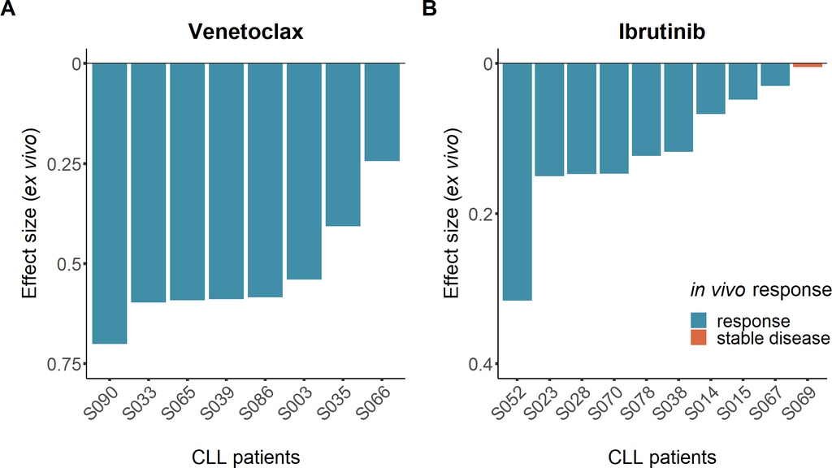

```r
design1<-"
AB
"

tp<-theme(plot.tag = element_text(size=22, face="bold"))

figure_CLL<-
  wrap_elements(plot_ven)+tp+
  wrap_elements(plot_ibr)+tp+
  plot_layout(design=design1)+
  plot_annotation(tag_levels ="A") & theme(title = element_text(size=18))

figure_CLL
```

```r
ggsave(path=(paste0(filepath,"docs")), filename = "Figure_S10.pdf")
# remove(tp, plot_ibr, plot_ven, figure_CLL)
```

# 12 12 Quality assessment based on the type of sample material

(Analyses done by Miguel)  
**plate_mean_normVal of inner DMSO ctrls by sample_type: BM, LN, PB**

```r
anova_res <- filter(screenData, Drug== "DMSO", !edge) %>%
  group_by(plateID, material) %>% summarise(plate_mean_normVal = mean(normVal)) %>% ungroup() %>%
  mutate(material = factor(material, levels = unique(material)))
anova_res %>% DT::datatable(width = 700)
```

|  | plateID | material | plate_mean_normVal |
| --- | --- | --- | --- |
| 1 | Acute_S002_18SCPB0110_180419 | PB | 0.998644745501201 |
| 2 | Acute_S003_18SCBM0113_180419 | BM | 0.99523062041933 |
| 3 | Acute_S005_18LN0082_180502 | LN | 1.08410341884722 |
| 4 | Acute_S006_18SCPB0136_180502 | PB | 1.00700950788009 |
| 5 | Acute_S006_18SCPB0136_180505 | PB | 1.01295769500499 |
| 6 | Acute_S007_18SCPB0142_180505 | PB | 0.985719322676701 |
| 7 | Acute_S008_18SCPB0147_180506 | PB | 1.01078133188662 |
| 8 | Acute_S009_18SCBM0165_180517 | BM | 0.998035945895868 |
| 9 | Acute_S011_18SCPB0208_180613 | PB | 1.02218013798342 |
| 10 | Acute_S012_18SCBM0212_180613 | BM | 1.00073793045777 |

[output cut: 155 more lines]

**Show ANOVA res**

```r
m <- lm(plate_mean_normVal ~ material, data = anova_res)
summary(m)
```

```
##
## Call:
## lm(formula = plate_mean_normVal ~ material, data = anova_res)
##
## Residuals:
##      Min       1Q   Median       3Q      Max
## -0.16263 -0.01092 -0.00358  0.00641  0.27585
##
## Coefficients:
##             Estimate Std. Error t value Pr(>|t|)
## (Intercept)  1.00255    0.00313  320.77   <2e-16 ***
## materialBM  -0.00362    0.00763   -0.47     0.64
## materialLN   0.00192    0.00925    0.21     0.84
## ---
## Signif. codes:  0 '***' 0.001 '**' 0.01 '*' 0.05 '.' 0.1 ' ' 1
##
## Residual standard error: 0.0348 on 162 degrees of freedom
## Multiple R-squared:  0.00186,    Adjusted R-squared:  -0.0105
## F-statistic: 0.151 on 2 and 162 DF,  p-value: 0.86
```

```r
remove(anova_res, m)
```

**Show plate median sdev and range**

```r
filter(screenData, Drug== "DMSO", !edge) %>% group_by(plateID, patientID) %>%
  summarise(plate_sdev = round(sd(normVal),4) ) %>% ungroup() %>%
  summarise(median_sdev = round(median(plate_sdev),4 ),
            range_sdev = paste0( round(range(plate_sdev)[1],4) ,
                                 " - ", range(plate_sdev)[2] ))
```

```
## # A tibble: 1 × 2
##   median_sdev range_sdev
##         <dbl> <chr>
## 1      0.0759 0.0293 - 0.6159
```

**prepare data**

```r
plotTab <- select(screenData, plateID, plate_sdev, plate, material, frozen) %>% unique() %>%
  #change names of categories
  mutate(material = ifelse(material == "BM","Bone marrow",
                           ifelse(material == "LN","Lymph node", "Peripheral blood")),
         frozen = ifelse(frozen == TRUE,"Frozen","Fresh"),
         plate = ifelse(plate== "Acute","Myeloid","Lymphoid"))
```

**show fig**

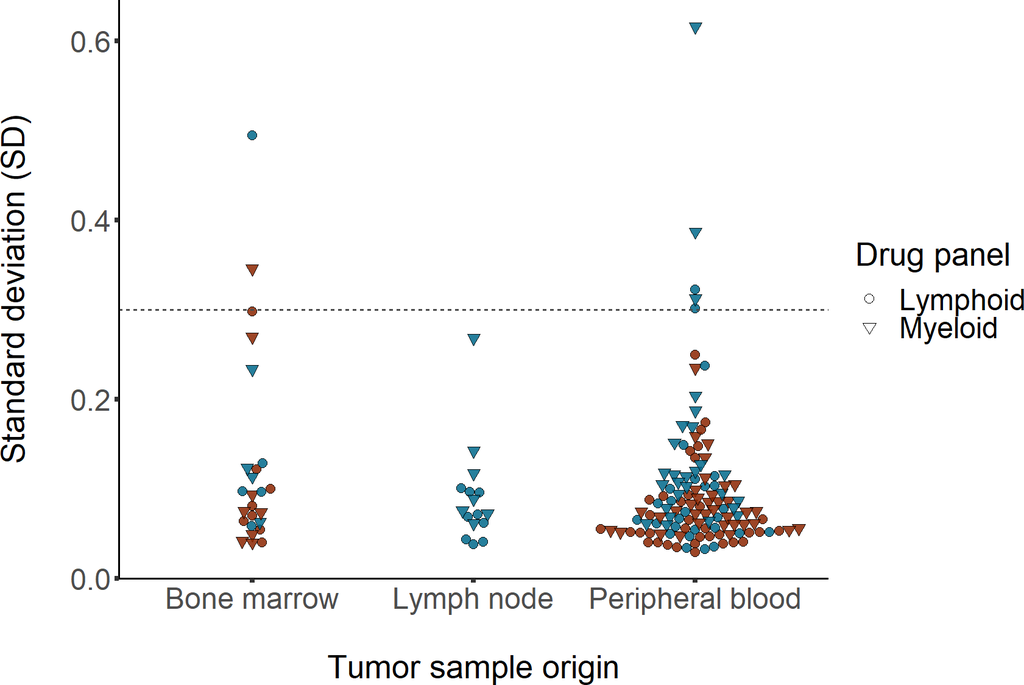

```r
p1<-ggplot(plotTab, aes(x = material, y = plate_sdev, fill = frozen, shape = plate)) +
  geom_point(aes(color= plate), alpha = 0, size=2.5) +
  geom_beeswarm(cex=1.5, size=2.5, alpha= 0.85, show.legend = F) +
  scale_shape_manual(values = c("Myeloid" = 25, "Lymphoid" = 21)) +
  #scale_color_manual(values = c("Fresh"="darkred","Frozen"="deepskyblue4")) +
  #scale_fill_manual(values = c("Fresh"="darkred","Frozen"="deepskyblue4")) +
  scale_color_manual(values = c("Fresh"=red2,"Frozen"=blue1)) +
  scale_fill_manual(values = c("Fresh"=red2,"Frozen"=blue1)) +
  geom_hline(yintercept = 0.3, linetype="22", col="gray30", size=0.7) +

  labs(color= "Material", shape = "Drug panel") +
    ylab("Standard deviation (SD)\n") +
    xlab("\nTumor sample origin") +
    guides(fill = "none",
           color = guide_legend(override.aes = list(alpha = 1), reverse = T, nrow=2),
           shape = guide_legend(override.aes = list(alpha = 1), nrow=2)) +
   theme_figures+
  theme(legend.position = "right")
p1
```

```r
ggsave( path=(paste0(filepath,"docs")), filename = "Figure_S1_Quality_assessment.pdf")
remove(plotTab)
```

## 12.1 12.1 Drug Drug Correlation

```r
cor.mat <-
  select(data_all, patientID, Drug,  AUC) %>%
  pivot_wider(names_from = Drug, values_from = AUC)%>%
  column_to_rownames("patientID") %>%
  rstatix::cor_mat()

cor.mat <- column_to_rownames(cor.mat, var="rowname")

breaks <- c(seq(-1, 1, length.out = 101)) %>% `names<-`(
     colorRampPalette(c("#003DA5", "#2055B0", "#406EBC", "#6086C7", "#809ED2", "#9FB6DD", "#BFCFE9", "#DFE7F4", "white", "#F4E0E7", "#E9C2CF", "#DEA3B6", "#D3849E", "#C76586", "#BC476E", "#B12855", "#A6093D"))(101))

pheatmap::pheatmap(cor.mat,
         breaks = breaks,
         color= names(breaks),
         border_color=NA,
         fontsize = 7,
         filename=paste0(filepath,"docs/Figure_S2.pdf"),
         width = 14,
         height = 14)


# ggsave( path=(paste0(filepath,"docs")), filename = "Figure_S2.pdf")

# unique(data_all$patientID) %>% length()
```

## 12.2 12.2 Raw viability between fresh and frozen samples

```r
screenData %>%
  select(patientID, material, frozen) %>%
  unique() %>%
  group_by(material, frozen) %>%
  count()
```

```
## # A tibble: 5 × 3
## # Groups:   material, frozen [5]
##   material frozen     n
##   <fct>    <lgl>  <int>
## 1 PB       FALSE     35
## 2 PB       TRUE      26
## 3 BM       FALSE      8
## 4 BM       TRUE       5
## 5 LN       TRUE       9
```

### 12.2.1 Per Plate

CAVE: This treats plates as replicates

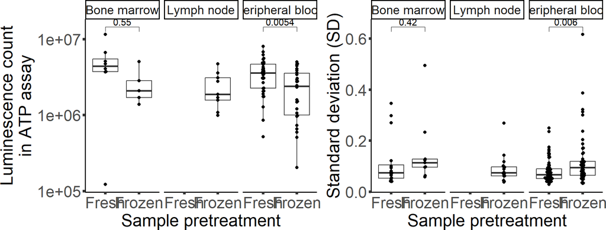

```r
p1<-screenData %>%
  filter(Drug %in% c("DMSO","PBS"), !edge) %>%
  group_by(patientID, frozen, material) %>%
  summarise(value=mean(value), sdev=mean(plate_sdev), .groups="keep") %>%
  mutate(material = ifelse(material == "BM","Bone marrow",
                    ifelse(material == "LN","Lymph node", "Peripheral blood")),
         frozen = ifelse(frozen == TRUE,"Frozen","Fresh")) %>%

ggplot(aes(x=frozen, y=value))+
  geom_boxplot()+
  geom_beeswarm()+
  stat_compare_means(method="t.test", comparisons = list(c(1,2)))+
  facet_wrap(~material)+
  scale_y_log10()+
  labs(y="Luminescence count\nin ATP assay", x="Sample pretreatment")+
  theme_figures


p2<-select(screenData, plateID, plate_sdev, plate, material, frozen) %>% unique() %>%
  mutate(material = ifelse(material == "BM","Bone marrow",
                    ifelse(material == "LN","Lymph node", "Peripheral blood")),
         frozen = ifelse(frozen == TRUE,"Frozen","Fresh")) %>%

ggplot(aes(x=frozen, y=plate_sdev))+
  geom_boxplot()+
  geom_beeswarm()+
  stat_compare_means(method="t.test", comparisons = list(c(1,2)))+
  facet_wrap(~material)+
  labs(y="Standard deviation (SD)", x="Sample pretreatment")+
  theme_figures

p1+p2
```

### 12.2.2 Per Patient sample

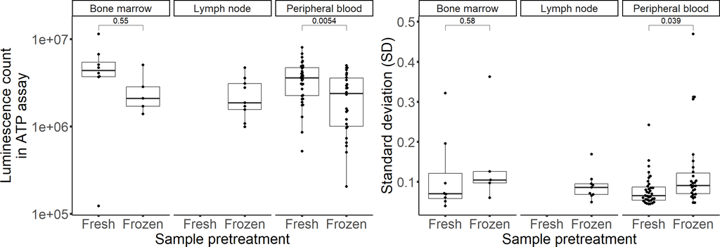

```r
p1<-screenData %>%
  filter(Drug %in% c("DMSO","PBS"), !edge) %>%
  group_by(patientID, frozen, material) %>%
  summarise(value=mean(value), sdev=mean(plate_sdev), .groups="keep") %>%
  mutate(material = ifelse(material == "BM","Bone marrow",
                    ifelse(material == "LN","Lymph node", "Peripheral blood")),
         frozen = ifelse(frozen == TRUE,"Frozen","Fresh")) %>%

ggplot(aes(x=frozen, y=value))+
  geom_boxplot()+
  geom_beeswarm()+
  stat_compare_means(method="t.test", comparisons = list(c(1,2)))+
  facet_wrap(~material)+
  scale_y_log10()+
  labs(y="Luminescence count\nin ATP assay", x="Sample pretreatment")+
  theme_figures


p2<-select(screenData, patientID, plateID, plate_sdev, plate, material, frozen) %>%
  group_by(patientID, frozen, material) %>%
  summarise(plate_sdev=mean(plate_sdev), .groups="keep") %>%
  # unique() %>%
  mutate(material = ifelse(material == "BM","Bone marrow",
                    ifelse(material == "LN","Lymph node", "Peripheral blood")),
         frozen = ifelse(frozen == TRUE,"Frozen","Fresh")) %>%

ggplot(aes(x=frozen, y=plate_sdev))+
  geom_boxplot()+
  geom_beeswarm(cex=2)+
  stat_compare_means(method="t.test", comparisons = list(c(1,2)))+
  facet_wrap(~material)+
  labs(y="Standard deviation (SD)", x="Sample pretreatment")+
  theme_figures

p1+p2
```

# 13 13 Genotype - phenotype associations

## 13.1 13.1 FLT3-ITD ratio & FLT3 inhibitors

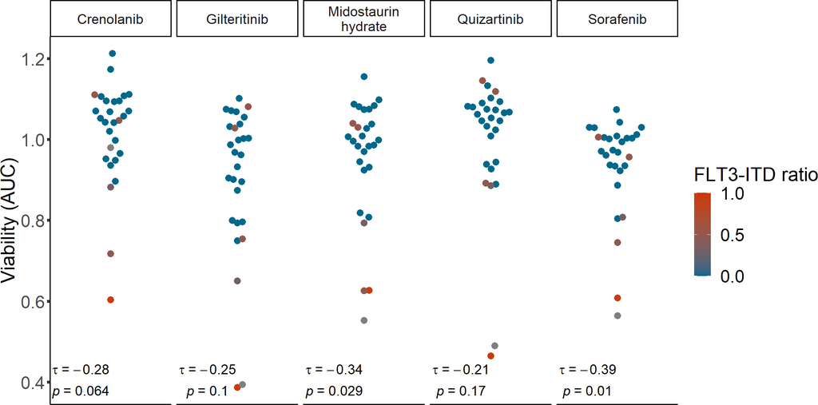

```r
# prepare data
tmp<-data_all%>%
  # here all AML patients with an available information about FLT3-ITD mutation were considered, even if patients had no evaluable response they were included because here we have no       correlation with in-vivo response
  filter(diagnosis=="AML")%>%
  filter(!is.na(FLT3_ITD_ratio), FLT3_ITD_ratio!="na")%>%
  # only FLT3 inhibnitors are considered
  filter(Drug=="Crenolanib" | Drug=="Gilteritinib" | Drug=="Quizartinib"| Drug=="Sorafenib"| Drug=="Midostaurin hydrate")%>%
  mutate(Drug=ifelse(Drug=="Midostaurin hydrate", "Midostaurin\nhydrate", Drug)) %>%
  select(patientID, Target, diagnosis, FLT3_ITD_ratio, Drug_response_mean_low, Drug)

# correlation plot
plot_S2A<-tmp%>%ggplot(aes(x=Drug, y=Drug_response_mean_low, color=FLT3_ITD_ratio))+
  geom_beeswarm(size=3, alpha=1, cex=5) +
  scale_color_gradientn(colors=c(blue1, red1), limits=c(0,1), name="FLT3-ITD ratio", breaks=c(0,0.5,1.0))+
  scale_y_continuous(name="Viability (AUC)")+
  theme_figures+
  stat_cor(aes(x=FLT3_ITD_ratio, y=Drug_response_mean_low), method="kendall",  cor.coef.name = c("tau"), label.sep="\n", label.x.npc=0.4, label.y.npc = 0.04, size=5)+
  facet_wrap(~ Drug, nrow=1, scales="free_x")+
  theme(axis.text.x = element_blank(),
        axis.ticks.x=element_blank(),
        axis.title.x = element_blank())

plot_S2A
```

## 13.2 13.2 FLT3-TKD & FLT3 inhibitors

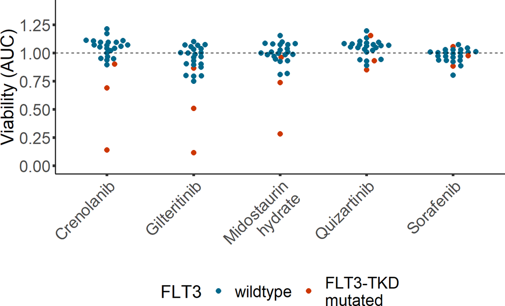

```r
# prepare dataset
tmp<-data_all%>%
  # here all AML patients with an available information about FLT3-ITD mutation were considered, even if patients had no evaluable response they were included because here we have no       correlation with in-vivo response, only patients with FLT3-TKD mutation but not FLT3-ITD mutation are considered
  filter(diagnosis=="AML")%>%
  filter(!is.na(FLT3), FLT3!="na")%>%
  filter(FLT3_TKD==1 | FLT3==0)%>%
  # only FLT3 inhibnitors are considered
  filter(Drug=="Crenolanib" | Drug=="Gilteritinib" | Drug=="Quizartinib"| Drug=="Sorafenib"| Drug=="Midostaurin hydrate")%>%
  mutate(Drug=ifelse(Drug=="Midostaurin hydrate", "Midostaurin\nhydrate", Drug)) %>%
  select(patientID, Target, diagnosis, FLT3, Drug_response_mean_low, Drug)

# plot
plot_S2B<-ggplot(tmp, aes(x=Drug,y=Drug_response_mean_low,color=FLT3))+
  geom_beeswarm(size=2.5, alpha=1, cex = 1.8)+
  scale_color_manual(values=c(blue1, red1), name="", label=c("wildtype", "FLT3-TKD\nmutated"))+
  scale_x_discrete(name="")+
  scale_y_continuous(name="Viability (AUC)", limits=c(0, 1.4), breaks=c(0, 0.25, 0.5, 0.75, 1, 1.25))+
  geom_hline(aes(yintercept=1), colour="black",
                linetype="dashed")  +
  theme_figures_x_angle_45+
  guides(color=guide_legend(title="FLT3", nrow=1))+
  theme(legend.position = "bottom", axis.title.x = element_blank() )

plot_S2B
```

```r
remove(tmp)
```

## 13.3 13.3 IDH mutations and venetoclax

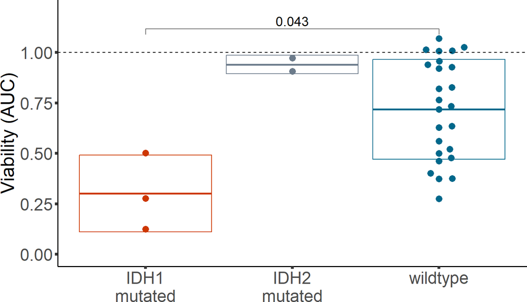

```r
# prepare dataset
tmp<- data_all%>%
  # here all AML patients with an available information about IDH mutation were considered, even if patients had no evaluable response they were included because here we have no            correlation with in-vivo response
  filter(diagnosis=="AML")%>%
  filter(Drug=="Venetoclax")%>%
  select(patientID, IDH1, IDH2, Drug, Pathway, AUC)%>%
  mutate(IDH=case_when(IDH1==1 ~ "IDH1\nmutated", IDH2==1 ~ "IDH2\nmutated", IDH1==0 & IDH2==0 ~ "wildtype", IDH1=="na" & IDH2=="na"~ "NA" ))%>%
  filter(IDH!="NA")

# plot
plot_S2C<-ggplot(tmp, aes(x=IDH,y=AUC,color=IDH))+
# geom_boxplot()+
  geom_boxplot(data=summarise(group_by(tmp, IDH), mean=mean(AUC), sd=sd(AUC), .groups = "keep"),
               aes(x=IDH,color=IDH,lower=mean-sd,upper=mean+sd,middle=mean,ymin=mean-sd,ymax=mean+sd),
               stat="identity", inherit.aes=FALSE)+
  geom_beeswarm(size=3, cex=3)+
 scale_color_manual(values=c(red1, gray1, blue1))+
  scale_y_continuous(name="Viability (AUC)", limits=c(0, 1.2), breaks=c(0, 0.25, 0.5, 0.75, 1))+
  geom_hline(aes(yintercept=1), colour="black",
                linetype="dashed")  +
  ggpubr::stat_compare_means(method = "t.test",paired=F,  size=starsize, comparisons = list( c(1,3)))+
  theme_figures_wo_legend+
  xlab("")

plot_S2C
```

```r
remove(tmp)
```

## 13.4 13.4 Nutlin-3a and TP53

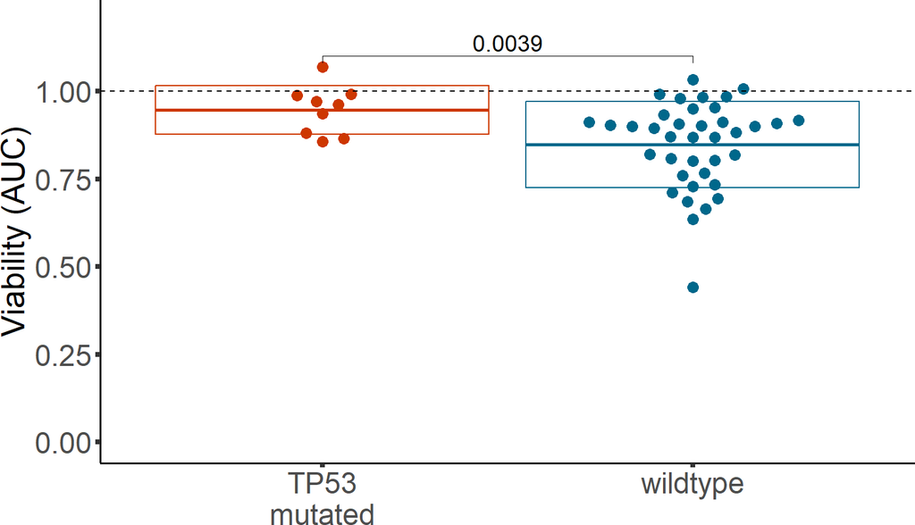

```r
# prepare dataset
tmp<-data_all%>%
  filter(!is.na(TP53), TP53!="na")%>%group_by(patientID,  TP53)%>%
  filter(Drug=="Nutlin-3a")%>%mutate(TP53=case_when(TP53==1 ~ "TP53\nmutated", TP53==0 ~ "wildtype"))

# plot
plot_S2D<-ggplot(tmp, aes(x= TP53,
             y=AUC,
             color=TP53))+
  geom_boxplot(data=summarise(group_by(tmp, TP53), mean=mean(AUC), sd=sd(AUC), .groups = "keep"),
               aes(x=TP53,color=TP53,lower=mean-sd,upper=mean+sd,middle=mean,ymin=mean-sd,ymax=mean+sd),
               stat="identity", inherit.aes=FALSE)+
  geom_beeswarm(size=3, cex=3)+
  scale_y_continuous(name="Viability (AUC)", limits=c(0, 1.2), breaks=c(0, 0.25, 0.5, 0.75, 1))+
  geom_hline(aes(yintercept=1), colour="black",
                linetype="dashed")  +
  scale_x_discrete(name="")+
  scale_color_manual(values=c(red1, blue1))+
  ggpubr::stat_compare_means(method = "t.test",paired=F,  size=starsize, comparisons = list( c(1,2)))+
  theme_figures_wo_legend
plot_S2D
```

```r
remove(tmp)
```